# Lab3_Papko

## Что сделано:

- Выполнены все 5 пунктов лабораторной. Задания подкреплены комментариями
- Теперь разделение датасета происходит на train, test, val, а не только на train и val
- Разделение на выборки теперь происходит в функции train_test_val_split
- Функции print_metrics, as_matrix изменена для возможности работы с рекурентными сетями
- Все эксперименты подкреплены графиками Loss, MSE, MAE

# Large scale text analysis with deep learning (3 points)

Today we're gonna apply the newly learned tools for the task of predicting job salary.

[figure not shown]

*Special thanks to [Oleg Vasilev](https://github.com/Omrigan/) for the core assignment idea.*

```python
from google.colab import drive
drive.mount('/content/drive')
```

```python
import numpy as np
import pandas as pd
import matplotlib.pyplot as plt
from sklearn.model_selection import train_test_split
%matplotlib inline
```

### About the challenge

You can also get it from [yadisk url](https://yadi.sk/d/vVEOWPFY3NruT7) the competition [page](https://www.kaggle.com/c/job-salary-prediction/data) (pick `Train_rev1.*`).

```python
data = pd.read_csv("/content/drive/MyDrive/ИАД_ЛАБ3/Train_rev1.csv", index_col=None)
data.shape
```

```
(244768, 12)
```

```python
data.head()
```

|  | Id | Title | FullDescription | LocationRaw | LocationNormalized | ContractType | ContractTime | Company | Category | SalaryRaw | SalaryNormalized | SourceName |
| --- | --- | --- | --- | --- | --- | --- | --- | --- | --- | --- | --- | --- |
| 0 | 12612628 | Engineering Systems Analyst | Engineering Systems Analyst Dorking Surrey Sal... | Dorking, Surrey, Surrey | Dorking | NaN | permanent | Gregory Martin International | Engineering Jobs | 20000 - 30000/annum 20-30K | 25000 | cv-library.co.uk |
| 1 | 12612830 | Stress Engineer Glasgow | Stress Engineer Glasgow Salary **** to **** We... | Glasgow, Scotland, Scotland | Glasgow | NaN | permanent | Gregory Martin International | Engineering Jobs | 25000 - 35000/annum 25-35K | 30000 | cv-library.co.uk |
| 2 | 12612844 | Modelling and simulation analyst | Mathematical Modeller / Simulation Analyst / O... | Hampshire, South East, South East | Hampshire | NaN | permanent | Gregory Martin International | Engineering Jobs | 20000 - 40000/annum 20-40K | 30000 | cv-library.co.uk |
| 3 | 12613049 | Engineering Systems Analyst / Mathematical Mod... | Engineering Systems Analyst / Mathematical Mod... | Surrey, South East, South East | Surrey | NaN | permanent | Gregory Martin International | Engineering Jobs | 25000 - 30000/annum 25K-30K negotiable | 27500 | cv-library.co.uk |
| 4 | 12613647 | Pioneer, Miser Engineering Systems Analyst | Pioneer, Miser Engineering Systems Analyst Do... | Surrey, South East, South East | Surrey | NaN | permanent | Gregory Martin International | Engineering Jobs | 20000 - 30000/annum 20-30K | 25000 | cv-library.co.uk |

One problem with salary prediction is that it's oddly distributed: there are many people who are paid standard salaries and a few that get tons o money. The distribution is fat-tailed on the right side, which is inconvenient for MSE minimization.

There are several techniques to combat this: using a different loss function, predicting log-target instead of raw target or even replacing targets with their percentiles among all salaries in the training set. We gonna use logarithm for now.

*You can read more [in the official description](https://www.kaggle.com/c/job-salary-prediction#description).*

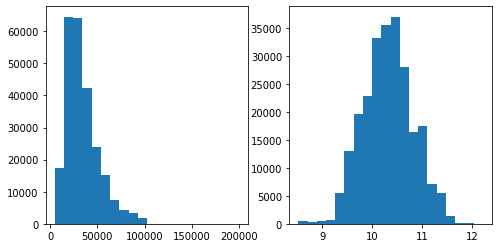

```python
data['Log1pSalary'] = np.log1p(data['SalaryNormalized']).astype('float32')

plt.figure(figsize=[8, 4])
plt.subplot(1, 2, 1)
plt.hist(data["SalaryNormalized"], bins=20);

plt.subplot(1, 2, 2)
plt.hist(data['Log1pSalary'], bins=20);
```

Our task is to predict one number, **Log1pSalary**.

To do so, our model can access a number of features:

- Free text: **`Title`** and **`FullDescription`**
- Categorical: **`Category`**, **`Company`**, **`LocationNormalized`**, **`ContractType`**, and **`ContractTime`**.

```python
text_columns = ["Title", "FullDescription"]
categorical_columns = ["Category", "Company", "LocationNormalized", "ContractType", "ContractTime"]
TARGET_COLUMN = "Log1pSalary"

data[categorical_columns] = data[categorical_columns].fillna('NaN') # cast missing values to string "NaN"
data[text_columns] = data[text_columns].fillna('NaN')

data.sample(3)
```

|  | Id | Title | FullDescription | LocationRaw | LocationNormalized | ContractType | ContractTime | Company | Category | SalaryRaw | SalaryNormalized | SourceName | Log1pSalary |
| --- | --- | --- | --- | --- | --- | --- | --- | --- | --- | --- | --- | --- | --- |
| 29536 | 68049531 | BI Sql Analyst | My client are a market leader in their field a... | Coventry | Coventry | NaN | permanent | NaN | IT Jobs | 25000.00 - 30000.00 per annum + excellent bene... | 27500 | theitjobboard.co.uk | 10.221977 |
| 183493 | 71625221 | PartTime PA/Admin | Part time PA/Admin AssistantSutton, Surrey ***... | Sutton - Sutton | Sutton | part_time | permanent | UKStaffsearch | Admin Jobs | 18000 - 20000 | 19000 | ukstaffsearch.com | 9.852247 |
| 106210 | 69591027 | Media Field Sales Consultant **** Basic **** U... | Marketing Consultant **** Basic, **** Uncappe... | Birmingham West Midlands (County) West Midlands | UK | NaN | permanent | Hibu | Sales Jobs | 28000 - 40250 per annum + Uncapped OTE, Car, P... | 34125 | totaljobs.com | 10.437815 |

### Preprocessing text data

Just like last week, applying NLP to a problem begins from tokenization: splitting raw text into sequences of tokens (words, punctuation, etc).

**Your task** is to lowercase and tokenize all texts under `Title` and `FullDescription` columns. Store the tokenized data as a **space-separated** string of tokens for performance reasons.

It's okay to use nltk tokenizers. Assertions were designed for WordPunctTokenizer, slight deviations are okay.

```python
print("Raw text:")
print(data["FullDescription"][2::100000])
```

```
Raw text:
2         Mathematical Modeller / Simulation Analyst / O...
100002    A successful and high achieving specialist sch...
200002    Web Designer  HTML, CSS, JavaScript, Photoshop...
Name: FullDescription, dtype: object
```

```python
import nltk
#TODO YOUR CODE HERE

tokenizer = nltk.tokenize.WordPunctTokenizer()
# YOUR CODE HERE

data[text_columns] = data[text_columns].applymap(lambda x: " ".join(tokenizer.tokenize(x.lower())))
```

Now we can assume that our text is a space-separated list of tokens:

```python
print("Tokenized:")
print(data["FullDescription"][2::100000])
assert data["FullDescription"][2][:50] == 'mathematical modeller / simulation analyst / opera'
assert data["Title"][54321] == 'international digital account manager ( german )'
```

```
Tokenized:
2         mathematical modeller / simulation analyst / o...
100002    a successful and high achieving specialist sch...
200002    web designer html , css , javascript , photosh...
Name: FullDescription, dtype: object
```

Not all words are equally useful. Some of them are typos or rare words that are only present a few times.

Let's count how many times is each word present in the data so that we can build a "white list" of known words.

```python
from collections import Counter
token_counts = Counter()
# Count how many times does each token occur in both "Title" and "FullDescription" in total
#TODO <YOUR CODE>

for col in text_columns:
    for line in data[col].values:
        token_counts.update(line.split(" "))
```

```python
print("Total unique tokens :", len(token_counts))
print('\n'.join(map(str, token_counts.most_common(n=5))))
print('...')
print('\n'.join(map(str, token_counts.most_common()[-3:])))

assert token_counts.most_common(1)[0][1] in  range(2600000, 2700000)
assert len(token_counts) in range(200000, 210000)
print('Correct!')
```

```
Total unique tokens : 202704
('and', 2657388)
('.', 2523216)
(',', 2318606)
('the', 2080994)
('to', 2019884)
...
('stephanietraveltraderecruitmnt', 1)
('ruabon', 1)
('lowehays', 1)
Correct!
```

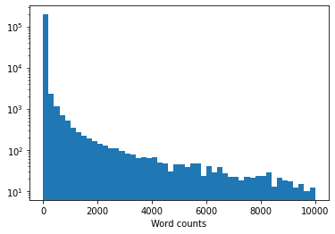

```python
# Let's see how many words are there for each count
plt.hist(list(token_counts.values()), range=[0, 10**4], bins=50, log=True)
plt.xlabel("Word counts");
```

**Task 1.1** Get a list of all tokens that occur at least 10 times.

```python
min_count = 10

# tokens from token_counts keys that had at least min_count occurrences throughout the dataset
#TODO <YOUR CODE>
tokens = sorted(t for t, c in token_counts.items() if c >= min_count)

# Add a special tokens for unknown and empty words
UNK, PAD = "UNK", "PAD"
tokens = [UNK, PAD] + tokens
```

```python
print("Vocabulary size:", len(tokens))
assert type(tokens) == list
assert len(tokens) in range(32000, 35000)
assert 'me' in tokens
assert UNK in tokens
print("Correct!")
```

```
Vocabulary size: 34158
Correct!
```

**Task 1.2** Build an inverse token index: a dictionary from token(string) to it's index in `tokens` (int)

```python
# TODO <YOUR CODE>
token_to_id = {t: i for i, t in enumerate(tokens)}
```

```python
assert isinstance(token_to_id, dict)
assert len(token_to_id) == len(tokens)
for tok in tokens:
    assert tokens[token_to_id[tok]] == tok

print("Correct!")
```

```
Correct!
```

And finally, let's use the vocabulary you've built to map text lines into neural network-digestible matrices.

```python
UNK_IX, PAD_IX = map(token_to_id.get, [UNK, PAD])
```

```python
def as_matrix(sequences, max_len=27):
    """ Convert a list of tokens into a matrix with padding """
    if isinstance(sequences[0], str):
        sequences = list(map(str.split, sequences))

    matrix = np.full((len(sequences), max_len), np.int32(PAD_IX))
    for i,seq in enumerate(sequences):
        row_ix = [token_to_id.get(word, UNK_IX) for word in seq[:max_len]]
        matrix[i, :len(row_ix)] = row_ix

    return matrix
```

```python
print("Lines:")
print('\n'.join(data["Title"][::100000].values), end='\n\n')
print("Matrix:")
print(as_matrix(data["Title"][::100000]))
```

```
Lines:
engineering systems analyst
hr assistant
senior ec & i engineer

Matrix:
[[10807 30161  2166     1     1     1     1     1     1     1     1     1
      1     1     1     1     1     1     1     1     1     1     1     1
      1     1     1]
 [15020  2844     1     1     1     1     1     1     1     1     1     1
      1     1     1     1     1     1     1     1     1     1     1     1
      1     1     1]
 [27645 10201    16 15215 10804     1     1     1     1     1     1     1
      1     1     1     1     1     1     1     1     1     1     1     1
      1     1     1]]
```

max_len установлено, как константное значение для создания матрицы фиксированного размера (необходимо для запуска архитектур с RNN/LSTM/GRU слоями)

Now let's encode the categirical data we have.

As usual, we shall use one-hot encoding for simplicity. Kudos if you implement more advanced encodings: tf-idf, pseudo-time-series, etc.

```python
from sklearn.feature_extraction import DictVectorizer

# we only consider top-1k most frequent companies to minimize memory usage
top_companies, top_counts = zip(*Counter(data['Company']).most_common(1000))
recognized_companies = set(top_companies)
data["Company"] = data["Company"].apply(lambda comp: comp if comp in recognized_companies else "Other")

categorical_vectorizer = DictVectorizer(dtype=np.float32, sparse=False)
categorical_vectorizer.fit(data[categorical_columns].apply(dict, axis=1))
```

```
DictVectorizer(dtype=<class 'numpy.float32'>, sparse=False)
```

### The deep learning part

Once we've learned to tokenize the data, let's design a machine learning experiment.

As before, we won't focus too much on validation, opting for a simple train-test split.

**To be completely rigorous,** we've comitted a small crime here: we used the whole data for tokenization and vocabulary building. A more strict way would be to do that part on training set only. You may want to do that and measure the magnitude of changes.

```python
def train_test_val_split(data, batch_size):
  data_train, data_test = train_test_split(data, test_size=0.1, random_state=77)

  data_test, data_val = train_test_split(data_test, test_size=0.5, random_state=77)

  data_train = data_train[:(len(data_train) // batch_size) * batch_size]
  data_test = data_test[:(len(data_test) // batch_size) * batch_size]
  data_val = data_val[:(len(data_val) // batch_size) * batch_size]

  return data_train, data_test, data_val
```

```python
def to_tensors(batch, device):
    batch_tensors = dict()
    for key, arr in batch.items():
        if key in ["FullDescription", "Title"]:
            batch_tensors[key] = torch.tensor(arr, device=device, dtype=torch.int64)
        else:
            batch_tensors[key] = torch.tensor(arr, device=device)
    return batch_tensors

def make_batch(data, max_len=27, word_dropout=0, device=torch.device('cpu')):
    """
    Creates a keras-friendly dict from the batch data.
    :param word_dropout: replaces token index with UNK_IX with this probability
    :returns: a dict with {'title' : int64[batch, title_max_len]
    """
    batch = {}
    batch["Title"] = as_matrix(data["Title"].values, max_len)
    batch["FullDescription"] = as_matrix(data["FullDescription"].values, max_len)
    batch['Categorical'] = categorical_vectorizer.transform(data[categorical_columns].apply(dict, axis=1))

    if word_dropout != 0:
        batch["FullDescription"] = apply_word_dropout(batch["FullDescription"], 1. - word_dropout)

    if TARGET_COLUMN in data.columns:
        batch[TARGET_COLUMN] = data[TARGET_COLUMN].values

    return to_tensors(batch, device)

def apply_word_dropout(matrix, keep_prop, replace_with=UNK_IX, pad_ix=PAD_IX,):
    dropout_mask = np.random.choice(2, np.shape(matrix), p=[keep_prop, 1 - keep_prop])
    dropout_mask &= matrix != pad_ix
    return np.choose(dropout_mask, [matrix, np.full_like(matrix, replace_with)])
```

#### Architecture

Our basic model consists of three branches:

- Title encoder
- Description encoder
- Categorical features encoder

We will then feed all 3 branches into one common network that predicts salary.

[figure not shown]

This clearly doesn't fit into keras' **Sequential** interface. To build such a network, one will have to use PyTorch.

```python
import torch
import torch.nn as nn
import torch.functional as F
```

```python
class SalaryPredictor(nn.Module):
    def __init__(self, n_tokens=len(tokens), n_cat_features=len(categorical_vectorizer.vocabulary_), hid_size=8):
        super().__init__()
        self.embedder = nn.Embedding(n_tokens, hid_size)
        self.title_encoder = nn.Sequential(
            nn.Conv1d(hid_size, hid_size, kernel_size=2),
            nn.Dropout(p=0.25),
            nn.ReLU(),
            nn.AdaptiveMaxPool1d(output_size=1)
        )
        self.description_encoder = nn.Sequential(
            nn.Conv1d(hid_size, hid_size, kernel_size=2),
            nn.Dropout(p=0.25),
            nn.ReLU(),
            nn.AdaptiveMaxPool1d(output_size=1)
        )
        self.categorical_encoder = nn.Sequential(
            nn.Linear(n_cat_features, hid_size * 2),
            nn.ReLU(),
            nn.Linear(hid_size * 2, hid_size * 2),
            nn.ReLU()
        )
        self.final_predictor = nn.Sequential(
            nn.Linear(hid_size * 4, hid_size),
            nn.ReLU(),
            nn.Linear(hid_size, 1)
        )
        #  YOUR CODE HERE


    def forward(self, batch):
        # YOUR CODE HERE
        title_embeddings = self.embedder(batch['Title']).permute(0, 2, 1)
        title_features = self.title_encoder(title_embeddings).squeeze()

        description_embeddings = self.embedder(batch['FullDescription']).permute(0, 2, 1)
        description_features = self.description_encoder(description_embeddings).squeeze()

        categorical_features = self.categorical_encoder(batch['Categorical'])
        # print(title_features.shape, description_features.shape, categorical_features.shape)
        features = torch.cat(
            [title_features, description_features, categorical_features], dim=1)

        return self.final_predictor(features).squeeze()
```

#### Training and evaluation

As usual, we gonna feed our monster with random minibatches of data.

As we train, we want to monitor not only loss function, which is computed in log-space, but also the actual error measured in dollars.

```python
def iterate_minibatches(data, batch_size=256, shuffle=True, cycle=False, **kwargs):
    """ iterates minibatches of data in random order """
    while True:
        indices = np.arange(len(data))
        if shuffle:
            indices = np.random.permutation(indices)

        for start in range(0, len(indices), batch_size):
            batch = make_batch(data.iloc[indices[start : start + batch_size]], **kwargs)
            yield batch

        if not cycle: break
```

### Model training

We can now fit our model the usual minibatch way. The interesting part is that we train on an infinite stream of minibatches, produced by `iterate_minibatches` function.

```python
import tqdm

EPOCHS = 2
BATCH_SIZE = 256
DEVICE = torch.device('cuda')
```

#### Train/test/val разделение

```python
data_train, data_test, data_val = train_test_val_split(data, BATCH_SIZE)

print("Train size =", len(data_train))
print("Test size =", len(data_test))
print("Validation size =", len(data_val))
```

```
Train size = 220160
Test size = 12032
Validation size = 12032
```

```python
def print_metrics(model, in_data, batch_size=BATCH_SIZE, h=None, name="", **kw):
    squared_error = abs_error = num_samples = 0.0
    model.eval()
    with torch.no_grad():
        for batch in iterate_minibatches(in_data, batch_size=batch_size, shuffle=False, **kw):
            '''print('Print metrics batch Title shape ', batch['Title'].shape)
            print('Print metrics batch Description shape ', batch['FullDescription'].shape)'''
            if h is not None:
              batch_pred = model(batch, h)
            else:
              batch_pred = model(batch)
            loss = criterion(batch_pred, batch[TARGET_COLUMN])
            squared_error += torch.mean(torch.square(batch_pred - batch[TARGET_COLUMN]))
            abs_error += torch.mean(torch.abs(batch_pred - batch[TARGET_COLUMN]))
            num_samples += len(batch)
    mse = squared_error.detach().cpu().numpy() / num_samples
    mae = abs_error.detach().cpu().numpy() / num_samples

    print("%s results:" % (name or ""))
    print("Loss: %.5f" % loss.item())
    print("Mean square error: %.5f" % mse)
    print("Mean absolute error: %.5f" % mae)

    return mse, mae
```

```python
def train(model, criterion, optimizer, has_reccurent = False):

  losses = []
  loss_iters = []
  metrics_iters = []
  train_mae = []
  train_mse = []
  test_mae = []
  test_mse = []

  cur_iter = 0

  for epoch in range(EPOCHS):
    print(f"epoch: {epoch}")
    if has_reccurent == True:
      h = model.init_hidden(BATCH_SIZE)
    for i, batch in tqdm.notebook.tqdm(enumerate(
            iterate_minibatches(
                    data_train,
                    batch_size=BATCH_SIZE,
                    device=DEVICE)),
                total=len(data_train) // BATCH_SIZE
        ):
        model.train()
        if has_reccurent == True:
          pred = model(batch, h)
        else:
          pred = model(batch)

        optimizer.zero_grad()
        loss = criterion(pred, batch[TARGET_COLUMN])
        loss_iters.append(cur_iter)

        losses.append(float(loss)/BATCH_SIZE)

        loss.backward()
        optimizer.step()

        if i % 100 == 99:
            if has_reccurent == True:
              val_h = model.init_hidden(BATCH_SIZE)
              mse, mae = print_metrics(model, data_train[:len(data_test)], name='train', batch_size=BATCH_SIZE, h=val_h, device=DEVICE)
              train_mse.append(mse)
              train_mae.append(mae)
              mse, mae = print_metrics(model, data_test, name='test', batch_size=BATCH_SIZE, h=val_h, device=DEVICE)
              test_mse.append(mse)
              test_mae.append(mae)
            else:
              mse, mae = print_metrics(model, data_train[:len(data_test)], name='train', batch_size=BATCH_SIZE, device=DEVICE)
              train_mse.append(mse)
              train_mae.append(mae)
              mse, mae = print_metrics(model, data_test, name='test', batch_size=BATCH_SIZE, device=DEVICE)
              test_mse.append(mse)
              test_mae.append(mae)
            metrics_iters.append(cur_iter)

        cur_iter += 1

  return losses, loss_iters, metrics_iters, train_mae, train_mse, test_mae, test_mse
```

```python
def show_plots(losses, loss_iters, metrics_iters, train_mae, train_mse, test_mae, test_mse, val_mse, val_mae):
  plt.plot(loss_iters[:2000], losses[:2000])
  plt.title("Training Loss Curve (batch_size={}, lr={})".format(BATCH_SIZE, 1e-3))
  plt.xlabel("Iterations")
  plt.ylabel("Loss")
  plt.show()

  plt.title("Train, Test MSE (batch_size={}, lr={})".format(BATCH_SIZE, 1e-3))
  plt.plot(metrics_iters, train_mse, label="Train MSE")
  plt.plot(metrics_iters, test_mse, label="Test MSE")
  plt.xlabel("Iterations")
  plt.ylabel("MSE")
  plt.legend(loc='best')
  plt.show()

  plt.title("Train, Test MAE (batch_size={}, lr={})".format(BATCH_SIZE, 1e-3))
  plt.plot(metrics_iters, train_mae, label="Train MAE")
  plt.plot(metrics_iters, test_mae, label="Test MAE")
  plt.xlabel("Iterations")
  plt.ylabel("MAE")
  plt.legend(loc='best')
  plt.show()

  print("Final Train MSE: {}".format(train_mse[-1]))
  print("Final Train MAE: {}".format(train_mae[-1]))
  print("Final Test MSE: {}".format(test_mse[-1]))
  print("Final Test MAE: {}".format(test_mae[-1]))
  print("Val MSE: {}".format(val_mse))
  print("Val MAE: {}".format(val_mae))
```

#### Стандартная модель из ноутбука

```python
model = SalaryPredictor().to(DEVICE)
criterion = nn.MSELoss(reduction='mean')
optimizer = torch.optim.Adam(model.parameters(), lr=1e-3)

losses, loss_iters, metrics_iters, train_mae, train_mse, test_mae, test_mse = train(model, criterion, optimizer)
```

```
epoch: 0
```

```
train results:
Loss: 29.22649
Mean square error: 7.30841
Mean absolute error: 1.34409
test results:
Loss: 28.87804
Mean square error: 7.28794
Mean absolute error: 1.34230
train results:
Loss: 2.17206
Mean square error: 0.55795
Mean absolute error: 0.34001
test results:
Loss: 2.12119
Mean square error: 0.55238
Mean absolute error: 0.33870
train results:
Loss: 2.19953
Mean square error: 0.56594
Mean absolute error: 0.34893
test results:
Loss: 2.16429
Mean square error: 0.56137
Mean absolute error: 0.34772
train results:
Loss: 2.20822
Mean square error: 0.56788
Mean absolute error: 0.35398
test results:
Loss: 2.19522
Mean square error: 0.56379
Mean absolute error: 0.35282
train results:
Loss: 2.15755
Mean square error: 0.55279
Mean absolute error: 0.35187
test results:
Loss: 2.15500
Mean square error: 0.54881
Mean absolute error: 0.35073
```

[output cut: 10 more lines]

```
Mean square error: 0.54014
Mean absolute error: 0.35029
test results:
Loss: 2.10301
Mean square error: 0.53651
Mean absolute error: 0.34907
train results:
Loss: 2.15522
Mean square error: 0.54349
Mean absolute error: 0.35235
test results:
Loss: 2.13071
Mean square error: 0.53953
Mean absolute error: 0.35098
epoch: 1
```

```
train results:
Loss: 2.04698
Mean square error: 0.51646
Mean absolute error: 0.34371
test results:
Loss: 2.01390
Mean square error: 0.51336
Mean absolute error: 0.34252
train results:
Loss: 2.12038
Mean square error: 0.53307
Mean absolute error: 0.35020
test results:
Loss: 2.08685
Mean square error: 0.52939
Mean absolute error: 0.34881
train results:
Loss: 2.10799
Mean square error: 0.52690
Mean absolute error: 0.34845
test results:
Loss: 2.06303
Mean square error: 0.52314
Mean absolute error: 0.34701
train results:
Loss: 2.06093
Mean square error: 0.51482
Mean absolute error: 0.34444
test results:
Loss: 2.03012
Mean square error: 0.51172
Mean absolute error: 0.34328
train results:
Loss: 2.03751
Mean square error: 0.51001
Mean absolute error: 0.34305
test results:
Loss: 2.00872
Mean square error: 0.50709
Mean absolute error: 0.34189
```

[output cut: 9 more lines]

```
Loss: 2.08039
Mean square error: 0.51821
Mean absolute error: 0.34656
test results:
Loss: 2.03768
Mean square error: 0.51480
Mean absolute error: 0.34518
train results:
Loss: 2.13793
Mean square error: 0.53082
Mean absolute error: 0.35128
test results:
Loss: 2.09045
Mean square error: 0.52698
Mean absolute error: 0.34979
```

```python
val_mse, val_mae = print_metrics(model, data_val, name='val', batch_size=BATCH_SIZE, device=DEVICE)
```

```
val results:
Loss: 2.01187
Mean square error: 0.47951
Mean absolute error: 0.33226
```

[figure not shown]

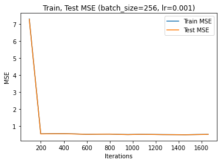

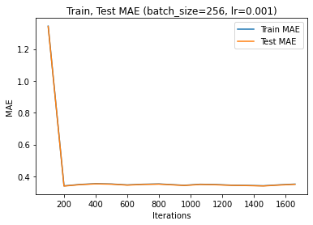

```
Final Train MSE: 0.530817762334296
Final Train MAE: 0.35127907610954123
Final Test MSE: 0.5269761998602684
Final Test MAE: 0.3497905731201172
Val MSE: 0.479510043529754
Val MAE: 0.33225915787067817
```

```python
show_plots(losses, loss_iters, metrics_iters, train_mae, train_mse, test_mae, test_mse, val_mse, val_mae)
```

Судя по графику loss, для обучения модели было достаточно 160-170 итераций

#### 1. Развейте СNN архитектуру (2 балла)

##### Добавим BatchNorm

Применим batchnorm перед нелинейностями, как в оригинальной статье (https://arxiv.org/pdf/1502.03167.pdf)

```python
class SalaryPredictor(nn.Module):
    def __init__(self, n_tokens=len(tokens), n_cat_features=len(categorical_vectorizer.vocabulary_), hid_size=8):
        super().__init__()
        self.embedder = nn.Embedding(n_tokens, hid_size)
        self.title_encoder = nn.Sequential(
            nn.Conv1d(hid_size, hid_size, kernel_size=2),
            nn.BatchNorm1d(hid_size),
            nn.ReLU(),
            nn.Dropout(p=0.25),
            nn.AdaptiveMaxPool1d(output_size=1)
        )
        self.description_encoder = nn.Sequential(
            nn.Conv1d(hid_size, hid_size, kernel_size=2),
            nn.BatchNorm1d(hid_size),
            nn.ReLU(),
            nn.Dropout(p=0.25),
            nn.AdaptiveMaxPool1d(output_size=1)
        )

        self.categorical_encoder = nn.Sequential(
            nn.Linear(n_cat_features, hid_size * 2),
            nn.BatchNorm1d(hid_size * 2),
            nn.ReLU(),
            nn.Linear(hid_size * 2, hid_size * 2),
            nn.ReLU()
        )
        self.final_predictor = nn.Sequential(
            nn.Linear(hid_size * 4, hid_size),
            nn.BatchNorm1d(hid_size),
            nn.ReLU(),
            nn.Linear(hid_size, 1)
        )

    def forward(self, batch):
        title_embeddings = self.embedder(batch['Title']).permute(0, 2, 1)
        title_features = self.title_encoder(title_embeddings).squeeze()

        description_embeddings = self.embedder(batch['FullDescription']).permute(0, 2, 1)
        description_features = self.description_encoder(description_embeddings).squeeze()

        categorical_features = self.categorical_encoder(batch['Categorical'])

        features = torch.cat(
            [title_features, description_features, categorical_features], dim=1)

        return self.final_predictor(features).squeeze()
```

```python
model = SalaryPredictor().to(DEVICE)
criterion = nn.MSELoss(reduction='mean')
optimizer = torch.optim.Adam(model.parameters(), lr=1e-3)

losses, loss_iters, metrics_iters, train_mae, train_mse, test_mae, test_mse = train(model, criterion, optimizer)
```

```
epoch: 0
```

```
train results:
Loss: 98.51797
Mean square error: 24.62965
Mean absolute error: 2.47793
test results:
Loss: 97.72427
Mean square error: 24.59424
Mean absolute error: 2.47615
train results:
Loss: 86.65383
Mean square error: 21.65255
Mean absolute error: 2.32196
test results:
Loss: 86.31034
Mean square error: 21.60871
Mean absolute error: 2.31958
train results:
Loss: 72.94212
Mean square error: 18.34860
Mean absolute error: 2.13535
test results:
Loss: 73.07243
Mean square error: 18.32000
Mean absolute error: 2.13376
train results:
Loss: 58.15436
Mean square error: 14.77084
Mean absolute error: 1.91276
test results:
Loss: 58.76434
Mean square error: 14.77005
Mean absolute error: 1.91294
train results:
Loss: 40.64238
Mean square error: 10.40584
Mean absolute error: 1.59707
test results:
Loss: 41.23991
Mean square error: 10.43452
Mean absolute error: 1.59962
```

[output cut: 10 more lines]

```
Mean square error: 4.12882
Mean absolute error: 0.98132
test results:
Loss: 16.26664
Mean square error: 4.16785
Mean absolute error: 0.98657
train results:
Loss: 11.91890
Mean square error: 3.09031
Mean absolute error: 0.83359
test results:
Loss: 12.03300
Mean square error: 3.13447
Mean absolute error: 0.84051
epoch: 1
```

```
train results:
Loss: 6.62255
Mean square error: 1.74090
Mean absolute error: 0.58451
test results:
Loss: 6.61243
Mean square error: 1.78170
Mean absolute error: 0.59290
train results:
Loss: 4.00869
Mean square error: 1.04361
Mean absolute error: 0.43653
test results:
Loss: 3.96403
Mean square error: 1.07124
Mean absolute error: 0.44339
train results:
Loss: 4.51211
Mean square error: 1.16144
Mean absolute error: 0.45928
test results:
Loss: 4.38351
Mean square error: 1.19447
Mean absolute error: 0.46699
train results:
Loss: 3.77988
Mean square error: 0.99521
Mean absolute error: 0.42722
test results:
Loss: 3.78284
Mean square error: 1.02196
Mean absolute error: 0.43378
train results:
Loss: 2.90987
Mean square error: 0.75153
Mean absolute error: 0.35461
test results:
Loss: 2.81805
Mean square error: 0.77687
Mean absolute error: 0.36162
```

[output cut: 9 more lines]

```
Loss: 2.89356
Mean square error: 0.75968
Mean absolute error: 0.35930
test results:
Loss: 2.80353
Mean square error: 0.78547
Mean absolute error: 0.36647
train results:
Loss: 2.72046
Mean square error: 0.71325
Mean absolute error: 0.35308
test results:
Loss: 2.63594
Mean square error: 0.73649
Mean absolute error: 0.35952
```

```python
val_mse, val_mae = print_metrics(model, data_val, name='val', batch_size=BATCH_SIZE, device=DEVICE)
```

```
val results:
Loss: 2.88735
Mean square error: 0.72964
Mean absolute error: 0.35057
```

[figure not shown]

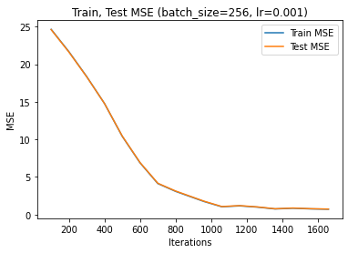

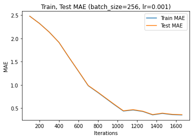

```
Final Train MSE: 0.7132544821881234
Final Train MAE: 0.3530751086295919
Final Test MSE: 0.7364908583620762
Final Test MAE: 0.35951914685837766
Val MSE: 0.729641447675989
Val MAE: 0.3505707192928233
```

```python
show_plots(losses, loss_iters, metrics_iters, train_mae, train_mse, test_mae, test_mse, val_mse, val_mae)
```

По какой-то причине наличие batchnorm снизило точность и скорость обучения модели, относительно стандартной модели

##### Параллельные сверточные слои

```python
class SalaryPredictor(nn.Module):
    def __init__(self, n_tokens=len(tokens), n_cat_features=len(categorical_vectorizer.vocabulary_), hid_size=8):
        super().__init__()
        self.embedder = nn.Embedding(n_tokens, hid_size)
        self.title_conv1 = nn.Conv1d(hid_size, hid_size, kernel_size=2)
        self.title_conv2 = nn.Conv1d(hid_size, hid_size, kernel_size=2)
        self.description_conv1 = nn.Conv1d(hid_size, hid_size, kernel_size=2)
        self.description_conv2 = nn.Conv1d(hid_size, hid_size, kernel_size=2)
        self.title_encoder = nn.Sequential(
            nn.ReLU(),
            nn.Dropout(p=0.25),
            nn.AdaptiveMaxPool1d(output_size=1)
        )
        self.description_encoder = nn.Sequential(
            nn.ReLU(),
            nn.Dropout(p=0.25),
            nn.AdaptiveMaxPool1d(output_size=1)
        )
        self.categorical_encoder = nn.Sequential(
            nn.Linear(n_cat_features, hid_size * 2),
            nn.ReLU(),
            nn.Linear(hid_size * 2, hid_size * 2),
            nn.ReLU()
        )
        self.final_predictor = nn.Sequential(
            nn.Linear(hid_size * 6, hid_size),
            nn.ReLU(),
            nn.Linear(hid_size, 1)
        )

    def forward(self, batch):
        title_embeddings = self.embedder(batch['Title']).permute(0, 2, 1)
        title_conv = torch.cat(
            [self.title_conv1(title_embeddings),
             self.title_conv2(title_embeddings)], dim=1)

        title_features = self.title_encoder(title_conv).squeeze()

        description_embeddings = self.embedder(batch['FullDescription']).permute(0, 2, 1)
        description_conv = torch.cat(
            [self.description_conv1(description_embeddings),
             self.description_conv2(description_embeddings)], dim=1)
        description_features = self.description_encoder(description_conv).squeeze()

        categorical_features = self.categorical_encoder(batch['Categorical'])

        features = torch.cat(
            [title_features, description_features, categorical_features], dim=1)

        return self.final_predictor(features).squeeze()
```

```python
model = SalaryPredictor().to(DEVICE)
criterion = nn.MSELoss(reduction='mean')
optimizer = torch.optim.Adam(model.parameters(), lr=1e-3)

losses, loss_iters, metrics_iters, train_mae, train_mse, test_mae, test_mse = train(model, criterion, optimizer)
```

```
epoch: 0
```

```
train results:
Loss: 21.09864
Mean square error: 5.17807
Mean absolute error: 1.12995
test results:
Loss: 20.48143
Mean square error: 5.15990
Mean absolute error: 1.12782
train results:
Loss: 3.15977
Mean square error: 0.73990
Mean absolute error: 0.40719
test results:
Loss: 2.87394
Mean square error: 0.73458
Mean absolute error: 0.40503
train results:
Loss: 3.06405
Mean square error: 0.71996
Mean absolute error: 0.40415
test results:
Loss: 2.80997
Mean square error: 0.71567
Mean absolute error: 0.40230
train results:
Loss: 3.00814
Mean square error: 0.71408
Mean absolute error: 0.40512
test results:
Loss: 2.80207
Mean square error: 0.71055
Mean absolute error: 0.40348
train results:
Loss: 2.95685
Mean square error: 0.70709
Mean absolute error: 0.40477
test results:
Loss: 2.79320
Mean square error: 0.70427
Mean absolute error: 0.40336
```

[output cut: 10 more lines]

```
Mean square error: 0.70345
Mean absolute error: 0.40539
test results:
Loss: 2.78243
Mean square error: 0.70063
Mean absolute error: 0.40410
train results:
Loss: 2.80774
Mean square error: 0.67782
Mean absolute error: 0.39797
test results:
Loss: 2.66777
Mean square error: 0.67503
Mean absolute error: 0.39674
epoch: 1
```

```
train results:
Loss: 2.76651
Mean square error: 0.66920
Mean absolute error: 0.39605
test results:
Loss: 2.64019
Mean square error: 0.66687
Mean absolute error: 0.39494
train results:
Loss: 2.80152
Mean square error: 0.67906
Mean absolute error: 0.39952
test results:
Loss: 2.67522
Mean square error: 0.67674
Mean absolute error: 0.39844
train results:
Loss: 2.74398
Mean square error: 0.66547
Mean absolute error: 0.39566
test results:
Loss: 2.61399
Mean square error: 0.66317
Mean absolute error: 0.39453
train results:
Loss: 2.72910
Mean square error: 0.66085
Mean absolute error: 0.39452
test results:
Loss: 2.59159
Mean square error: 0.65806
Mean absolute error: 0.39324
train results:
Loss: 2.72412
Mean square error: 0.66186
Mean absolute error: 0.39512
test results:
Loss: 2.59204
Mean square error: 0.65941
Mean absolute error: 0.39401
```

[output cut: 9 more lines]

```
Loss: 2.63488
Mean square error: 0.64061
Mean absolute error: 0.38889
test results:
Loss: 2.51467
Mean square error: 0.63833
Mean absolute error: 0.38782
train results:
Loss: 2.55948
Mean square error: 0.62600
Mean absolute error: 0.38440
test results:
Loss: 2.45294
Mean square error: 0.62366
Mean absolute error: 0.38334
```

```python
val_mse, val_mae = print_metrics(model, data_val, name='val', batch_size=BATCH_SIZE, device=DEVICE)
```

```
val results:
Loss: 2.58355
Mean square error: 0.61806
Mean absolute error: 0.38145
```

[figure not shown]

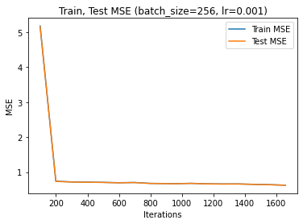

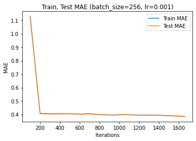

```
Final Train MSE: 0.626001479777884
Final Train MAE: 0.38440440563445394
Final Test MSE: 0.6236552786319813
Final Test MAE: 0.38333616865442155
Val MSE: 0.6180570074852477
Val MAE: 0.3814493950377119
```

```python
show_plots(losses, loss_iters, metrics_iters, train_mae, train_mse, test_mae, test_mse, val_mse, val_mae)
```

Итоговые показатели хуже, чем у дефолтной модели, но лучше, чем у модели с batchnorm

##### Параллельные сверточные слои с BatchNorm

```python
class SalaryPredictor(nn.Module):
    def __init__(self, n_tokens=len(tokens), n_cat_features=len(categorical_vectorizer.vocabulary_), hid_size=8):
        super().__init__()
        self.embedder = nn.Embedding(n_tokens, hid_size)
        self.title_conv1 = nn.Conv1d(hid_size, hid_size, kernel_size=2)
        self.title_conv2 = nn.Conv1d(hid_size, hid_size, kernel_size=2)
        self.description_conv1 = nn.Conv1d(hid_size, hid_size, kernel_size=2)
        self.description_conv2 = nn.Conv1d(hid_size, hid_size, kernel_size=2)
        self.title_encoder = nn.Sequential(
            nn.ReLU(),
            nn.Dropout(p=0.25),
            nn.AdaptiveMaxPool1d(output_size=1)
        )
        self.description_encoder = nn.Sequential(
            nn.ReLU(),
            nn.Dropout(p=0.25),
            nn.AdaptiveMaxPool1d(output_size=1)
        )

        self.categorical_encoder = nn.Sequential(
            nn.Linear(n_cat_features, hid_size * 2),
            nn.BatchNorm1d(hid_size * 2),
            nn.ReLU(),
            nn.Linear(hid_size * 2, hid_size * 2),
            nn.ReLU()
        )
        self.final_predictor = nn.Sequential(
            nn.Linear(hid_size * 6, hid_size),
            nn.BatchNorm1d(hid_size),
            nn.ReLU(),
            nn.Linear(hid_size, 1)
        )

    def forward(self, batch):
        title_embeddings = self.embedder(batch['Title']).permute(0, 2, 1)
        title_conv = torch.cat(
            [self.title_conv1(title_embeddings),
             self.title_conv2(title_embeddings)], dim=1)

        title_features = self.title_encoder(title_conv).squeeze()

        description_embeddings = self.embedder(batch['FullDescription']).permute(0, 2, 1)
        description_conv = torch.cat(
            [self.description_conv1(description_embeddings),
             self.description_conv2(description_embeddings)], dim=1)
        description_features = self.description_encoder(description_conv).squeeze()

        categorical_features = self.categorical_encoder(batch['Categorical'])

        features = torch.cat(
            [title_features, description_features, categorical_features], dim=1)

        return self.final_predictor(features).squeeze()
```

```python
model = SalaryPredictor().to(DEVICE)
criterion = nn.MSELoss(reduction='mean')
optimizer = torch.optim.Adam(model.parameters(), lr=1e-3)

losses, loss_iters, metrics_iters, train_mae, train_mse, test_mae, test_mse = train(model, criterion, optimizer)
```

```
epoch: 0
```

```
train results:
Loss: 90.07663
Mean square error: 22.40399
Mean absolute error: 2.36297
test results:
Loss: 88.75565
Mean square error: 22.38625
Mean absolute error: 2.36200
train results:
Loss: 77.84943
Mean square error: 19.47755
Mean absolute error: 2.20217
test results:
Loss: 77.20760
Mean square error: 19.47846
Mean absolute error: 2.20214
train results:
Loss: 66.43444
Mean square error: 16.62886
Mean absolute error: 2.03292
test results:
Loss: 66.20242
Mean square error: 16.64314
Mean absolute error: 2.03369
train results:
Loss: 52.79213
Mean square error: 13.20613
Mean absolute error: 1.80934
test results:
Loss: 52.89882
Mean square error: 13.20720
Mean absolute error: 1.80935
train results:
Loss: 40.15524
Mean square error: 10.08317
Mean absolute error: 1.57722
test results:
Loss: 40.15452
Mean square error: 10.07628
Mean absolute error: 1.57668
```

[output cut: 10 more lines]

```
Mean square error: 5.42028
Mean absolute error: 1.13968
test results:
Loss: 21.28472
Mean square error: 5.41202
Mean absolute error: 1.13889
train results:
Loss: 16.35988
Mean square error: 3.98176
Mean absolute error: 0.95679
test results:
Loss: 15.58493
Mean square error: 3.97752
Mean absolute error: 0.95641
epoch: 1
```

```
train results:
Loss: 8.17117
Mean square error: 1.99661
Mean absolute error: 0.64811
test results:
Loss: 7.81115
Mean square error: 2.00468
Mean absolute error: 0.64960
train results:
Loss: 6.90896
Mean square error: 1.65876
Mean absolute error: 0.55333
test results:
Loss: 6.41753
Mean square error: 1.66395
Mean absolute error: 0.55515
train results:
Loss: 5.72403
Mean square error: 1.37718
Mean absolute error: 0.48552
test results:
Loss: 5.45332
Mean square error: 1.37975
Mean absolute error: 0.48746
train results:
Loss: 4.11197
Mean square error: 0.98077
Mean absolute error: 0.40536
test results:
Loss: 3.92096
Mean square error: 0.98680
Mean absolute error: 0.40792
train results:
Loss: 4.12566
Mean square error: 0.97467
Mean absolute error: 0.41925
test results:
Loss: 3.83717
Mean square error: 0.97751
Mean absolute error: 0.42096
```

[output cut: 9 more lines]

```
Loss: 4.38080
Mean square error: 1.05354
Mean absolute error: 0.43070
test results:
Loss: 4.24129
Mean square error: 1.06347
Mean absolute error: 0.43395
train results:
Loss: 3.60073
Mean square error: 0.87491
Mean absolute error: 0.39943
test results:
Loss: 3.47003
Mean square error: 0.88079
Mean absolute error: 0.40218
```

```python
val_mse, val_mae = print_metrics(model, data_val, name='val', batch_size=BATCH_SIZE, device=DEVICE)
```

```
val results:
Loss: 2.28156
Mean square error: 0.61255
Mean absolute error: 0.33694
```

[figure not shown]

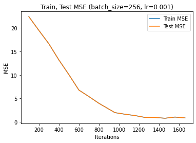

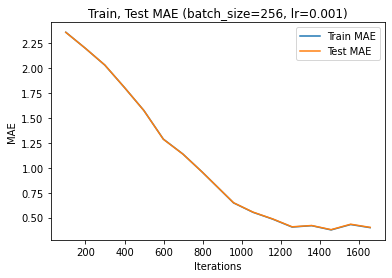

```
Final Train MSE: 0.874910314032372
Final Train MAE: 0.39942599357442654
Final Test MSE: 0.8807903857941323
Final Test MAE: 0.40217801357837435
Val MSE: 0.6125478135778549
Val MAE: 0.33693948705145654
```

```python
show_plots(losses, loss_iters, metrics_iters, train_mae, train_mse, test_mae, test_mse, val_mse, val_mae)
```

Худшая архитектура на данный момент

##### Добавим больше слоев и раннюю остановку

Для этого создадим соответствующую функцию и модель

```python
def train_with_early_stopping(model, criterion, optimizer):
  losses = []
  loss_iters = []
  metrics_iters = []
  train_mae = []
  train_mse = []
  test_mae = []
  test_mse = []

  cur_iter = 0
  last_loss = 1000
  patience = 5 # если mse увеличится 5 раз подряд, то обучение будет приостановлено
  trigger_times = 0
  mse = 0

  for epoch in range(EPOCHS):
    print(f"epoch: {epoch}")
    for i, batch in tqdm.notebook.tqdm(enumerate(
            iterate_minibatches(
                    data_train,
                    batch_size=BATCH_SIZE,
                    device=DEVICE)),
                total=len(data_train) // BATCH_SIZE
        ):
        model.train()
        pred = model(batch)
        optimizer.zero_grad()
        loss = criterion(pred, batch[TARGET_COLUMN])
        loss_iters.append(cur_iter)

        losses.append(float(loss)/BATCH_SIZE)

        loss.backward()
        optimizer.step()

        if i % 100 == 99:
            mse, mae = print_metrics(model, data_train[:len(data_test)], name='train', batch_size=BATCH_SIZE, device=DEVICE)
            train_mse.append(mse)
            train_mae.append(mae)
            mse, mae = print_metrics(model, data_test, name='test', batch_size=BATCH_SIZE, device=DEVICE)
            test_mse.append(mse)
            test_mae.append(mae)
            metrics_iters.append(cur_iter)

        if mse > last_loss:
            trigger_times += 1
            print('trigger times:', trigger_times)

            if trigger_times >= patience:
                raise Exception('Early stopping!')
        else:
            trigger_times = 0

        last_loss = mse

        cur_iter += 1

  return losses, loss_iters, metrics_iters, train_mae, train_mse, test_mae, test_mse
```

```python
class SalaryPredictor(nn.Module):
    def __init__(self, n_tokens=len(tokens), n_cat_features=len(categorical_vectorizer.vocabulary_), hid_size=8):
        super().__init__()
        self.embedder = nn.Embedding(n_tokens, hid_size)
        self.title_encoder = nn.Sequential(
            nn.Conv1d(hid_size, hid_size, kernel_size=2),
            nn.MaxPool1d(2),
            nn.Conv1d(hid_size, hid_size, kernel_size=1),
            nn.ReLU(),
            nn.Dropout(p=0.25),
            nn.AdaptiveMaxPool1d(output_size=1)
        )
        self.description_encoder = nn.Sequential(
            nn.Conv1d(hid_size, hid_size, kernel_size=2),
            nn.MaxPool1d(2),
            nn.Conv1d(hid_size, hid_size, kernel_size=1),
            nn.ReLU(),
            nn.Dropout(p=0.25),
            nn.AdaptiveMaxPool1d(output_size=1)
        )

        self.categorical_encoder = nn.Sequential(
            nn.Linear(n_cat_features, hid_size * 4),
            nn.ReLU(),
            nn.Linear(hid_size * 4, hid_size * 2),
            nn.BatchNorm1d(hid_size * 2),
            nn.ReLU(),
            nn.Linear(hid_size * 2, hid_size),
            nn.BatchNorm1d(hid_size),
            nn.ReLU()
        )
        self.final_predictor = nn.Sequential(
            nn.Linear(hid_size * 3, hid_size * 2),
            nn.BatchNorm1d(hid_size * 2),
            nn.ReLU(),
            nn.Linear(hid_size * 2, hid_size),
            nn.BatchNorm1d(hid_size),
            nn.ReLU(),
            nn.Linear(hid_size, 1)
        )

    def forward(self, batch):
        title_embeddings = self.embedder(batch['Title']).permute(0, 2, 1)
        title_features = self.title_encoder(title_embeddings).squeeze()

        description_embeddings = self.embedder(batch['FullDescription']).permute(0, 2, 1)
        description_features = self.description_encoder(description_embeddings).squeeze()

        categorical_features = self.categorical_encoder(batch['Categorical'])

        features = torch.cat(
            [title_features, description_features, categorical_features], dim=1)

        return self.final_predictor(features).squeeze()
```

```python
model = SalaryPredictor().to(DEVICE)
criterion = nn.MSELoss(reduction='mean')
optimizer = torch.optim.Adam(model.parameters(), lr=1e-3)

losses, loss_iters, metrics_iters, train_mae, train_mse, test_mae, test_mse = train_with_early_stopping(model, criterion, optimizer)
```

```
epoch: 0
```

```
train results:
Loss: 96.63870
Mean square error: 24.20489
Mean absolute error: 2.45647
test results:
Loss: 96.83582
Mean square error: 24.16434
Mean absolute error: 2.45452
trigger times: 1
train results:
Loss: 84.16229
Mean square error: 21.22887
Mean absolute error: 2.29789
test results:
Loss: 85.07281
Mean square error: 21.20939
Mean absolute error: 2.29699
train results:
Loss: 71.01845
Mean square error: 18.03655
Mean absolute error: 2.11364
test results:
Loss: 72.68712
Mean square error: 18.01032
Mean absolute error: 2.11224
train results:
Loss: 57.62087
Mean square error: 14.65014
Mean absolute error: 1.89622
test results:
Loss: 59.24915
Mean square error: 14.62043
Mean absolute error: 1.89449
train results:
Loss: 45.05738
Mean square error: 11.47833
Mean absolute error: 1.67589
test results:
Loss: 46.78556
Mean square error: 11.50067
```

[output cut: 11 more lines]

```
Mean square error: 5.57912
Mean absolute error: 1.12856
test results:
Loss: 24.07706
Mean square error: 5.60635
Mean absolute error: 1.13133
train results:
Loss: 13.95493
Mean square error: 3.52949
Mean absolute error: 0.88008
test results:
Loss: 15.58822
Mean square error: 3.55625
Mean absolute error: 0.88369
epoch: 1
```

```
train results:
Loss: 5.18448
Mean square error: 1.30868
Mean absolute error: 0.50170
test results:
Loss: 5.94629
Mean square error: 1.31780
Mean absolute error: 0.50313
train results:
Loss: 2.23511
Mean square error: 0.57655
Mean absolute error: 0.31538
test results:
Loss: 2.56864
Mean square error: 0.57853
Mean absolute error: 0.31563
train results:
Loss: 0.75536
Mean square error: 0.18494
Mean absolute error: 0.17480
test results:
Loss: 0.76564
Mean square error: 0.18513
Mean absolute error: 0.17472
train results:
Loss: 0.28669
Mean square error: 0.07243
Mean absolute error: 0.10495
test results:
Loss: 0.27011
Mean square error: 0.07241
Mean absolute error: 0.10524
train results:
Loss: 0.17220
Mean square error: 0.04307
Mean absolute error: 0.08137
test results:
Loss: 0.15421
Mean square error: 0.04370
Mean absolute error: 0.08151
```

[output cut: 11 more lines]

```
Mean square error: 0.06012
Mean absolute error: 0.09858
test results:
Loss: 0.20988
Mean square error: 0.06115
Mean absolute error: 0.09952
trigger times: 1
train results:
Loss: 0.20691
Mean square error: 0.05498
Mean absolute error: 0.09357
test results:
Loss: 0.19692
Mean square error: 0.05586
Mean absolute error: 0.09407
```

```python
val_mse, val_mae = print_metrics(model, data_val, name='val', batch_size=BATCH_SIZE, device=DEVICE)
```

```
val results:
Loss: 0.23141
Mean square error: 0.06277
Mean absolute error: 0.10085
```

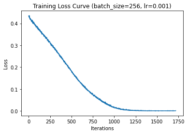

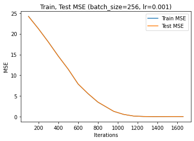

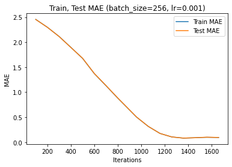

```
Final Train MSE: 0.05497625026297062
Final Train MAE: 0.0935744326165382
Final Test MSE: 0.05585576625580483
Final Test MAE: 0.09407281875610352
Val MSE: 0.06277429803888848
Val MAE: 0.10084602680612118
```

```python
show_plots(losses, loss_iters, metrics_iters, train_mae, train_mse, test_mae, test_mse, val_mse, val_mae)
```

Значения метрик получились ниже, чем во всех предыдущих экспериментах. Ранняя остановка не произошла, так как модель не переобучилась

#### 2. Pooling слои стандартные

1d Pooling слой сжимает входную последовательность в заданное количество раз (kernel_size). При kernel_size = 2 каждые 2 числа будут преобразовываться в одно. В случае с avgpool будет браться среднее между этими числами, в случае с maxpool будет браться максимальное число. Слои Adaptive Average pooling и Adaptive Max pooling будут брать среднее и максимально значения соответственно по всех входной последовательности и возвращать только одно среднее/максимальное значение. У 2d pooling принцип работы такой же, но работа ведется не с векторами, а с матрицами

##### Максимум по временной компоненте

```python
class SalaryPredictor(nn.Module):
    def __init__(self, n_tokens=len(tokens), n_cat_features=len(categorical_vectorizer.vocabulary_), hid_size=8):
        super().__init__()
        self.title_input_len = len(make_batch(data_train[:BATCH_SIZE])['Title'][0])
        self.description_input_len = len(make_batch(data_train[:BATCH_SIZE])['FullDescription'][0])
        self.embedder = nn.Embedding(n_tokens, hid_size)
        self.title_encoder = nn.Sequential(
            nn.Conv1d(hid_size, hid_size*2, kernel_size=2),
            nn.MaxPool1d(2),
            nn.Conv1d(hid_size*2, hid_size, kernel_size=1),
            nn.BatchNorm1d(hid_size),
            nn.ReLU(),
            nn.Dropout(p=0.25)
        )
        self.title_pooling = nn.AdaptiveMaxPool1d(output_size=1)
        self.description_encoder = nn.Sequential(
            nn.Conv1d(hid_size, hid_size*2, kernel_size=2),
            nn.MaxPool1d(2),
            nn.Conv1d(hid_size*2, hid_size, kernel_size=1),
            nn.BatchNorm1d(hid_size),
            nn.ReLU(),
            nn.Dropout(p=0.25)
        )
        self.description_pooling = nn.AdaptiveMaxPool1d(output_size=1)
        self.categorical_encoder = nn.Sequential(
            nn.Linear(n_cat_features, hid_size * 4),
            nn.ReLU(),
            nn.Linear(hid_size * 4, hid_size * 2),
            nn.BatchNorm1d(hid_size * 2),
            nn.ReLU(),
            nn.Linear(hid_size * 2, hid_size),
            nn.BatchNorm1d(hid_size),
            nn.ReLU()
        )
        self.final_predictor_in = 34
        self.final_predictor = nn.Sequential(
            nn.Linear(self.final_predictor_in, hid_size * 2),
            nn.BatchNorm1d(hid_size * 2),
            nn.ReLU(),
            nn.Linear(hid_size * 2, hid_size),
            nn.BatchNorm1d(hid_size),
            nn.ReLU(),
            nn.Linear(hid_size, 1)
        )

    def forward(self, batch):
        title_embeddings = self.embedder(batch['Title']).permute(0, 2, 1)
        title_features = self.title_encoder(title_embeddings).permute(0, 2, 1)
        title_pooling = self.title_pooling(title_features).squeeze()

        description_embeddings = self.embedder(batch['FullDescription']).permute(0, 2, 1)
        description_features = self.description_encoder(description_embeddings).permute(0, 2, 1)
        description_pooling = self.description_pooling(description_features).squeeze()

        categorical_features = self.categorical_encoder(batch['Categorical'])
        features = torch.cat(
            [title_pooling, description_pooling, categorical_features], dim=1)
        self.final_predictor_in = len(features[1])
        return self.final_predictor(features).squeeze()
```

```python
model = SalaryPredictor().to(DEVICE)
criterion = nn.MSELoss(reduction='mean')
optimizer = torch.optim.Adam(model.parameters(), lr=1e-3)

losses, loss_iters, metrics_iters, train_mae, train_mse, test_mae, test_mse = train(model, criterion, optimizer)
```

```
epoch: 0
```

```
train results:
Loss: 93.48908
Mean square error: 23.40785
Mean absolute error: 2.41514
test results:
Loss: 92.84671
Mean square error: 23.35882
Mean absolute error: 2.41268
train results:
Loss: 82.99770
Mean square error: 20.69493
Mean absolute error: 2.27041
test results:
Loss: 82.13753
Mean square error: 20.65494
Mean absolute error: 2.26837
train results:
Loss: 71.57767
Mean square error: 17.76852
Mean absolute error: 2.10240
test results:
Loss: 70.22767
Mean square error: 17.75149
Mean absolute error: 2.10147
train results:
Loss: 59.26106
Mean square error: 14.67322
Mean absolute error: 1.90852
test results:
Loss: 57.93182
Mean square error: 14.65670
Mean absolute error: 1.90744
train results:
Loss: 44.50179
Mean square error: 11.10061
Mean absolute error: 1.65696
test results:
Loss: 43.82284
Mean square error: 11.09051
Mean absolute error: 1.65621
```

[output cut: 10 more lines]

```
Mean square error: 4.19513
Mean absolute error: 1.01407
test results:
Loss: 16.42891
Mean square error: 4.16860
Mean absolute error: 1.01100
train results:
Loss: 7.55076
Mean square error: 1.90273
Mean absolute error: 0.67517
test results:
Loss: 7.53557
Mean square error: 1.88693
Mean absolute error: 0.67247
epoch: 1
```

```
train results:
Loss: 1.65210
Mean square error: 0.43344
Mean absolute error: 0.29978
test results:
Loss: 1.69326
Mean square error: 0.42520
Mean absolute error: 0.29699
train results:
Loss: 0.57497
Mean square error: 0.14598
Mean absolute error: 0.15668
test results:
Loss: 0.57686
Mean square error: 0.14172
Mean absolute error: 0.15426
train results:
Loss: 0.30121
Mean square error: 0.07662
Mean absolute error: 0.10799
test results:
Loss: 0.30114
Mean square error: 0.07431
Mean absolute error: 0.10629
train results:
Loss: 0.22636
Mean square error: 0.05973
Mean absolute error: 0.09366
test results:
Loss: 0.24036
Mean square error: 0.05881
Mean absolute error: 0.09308
train results:
Loss: 0.21022
Mean square error: 0.05962
Mean absolute error: 0.09346
test results:
Loss: 0.22433
Mean square error: 0.05832
Mean absolute error: 0.09274
```

[output cut: 9 more lines]

```
Loss: 0.17877
Mean square error: 0.04777
Mean absolute error: 0.08546
test results:
Loss: 0.18788
Mean square error: 0.04852
Mean absolute error: 0.08652
train results:
Loss: 0.17945
Mean square error: 0.04758
Mean absolute error: 0.08464
test results:
Loss: 0.18117
Mean square error: 0.04777
Mean absolute error: 0.08515
```

```python
val_mse, val_mae = print_metrics(model, data_val, name='val', batch_size=BATCH_SIZE, device=DEVICE)
```

```
val results:
Loss: 0.19416
Mean square error: 0.04433
Mean absolute error: 0.08214
```

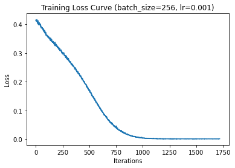

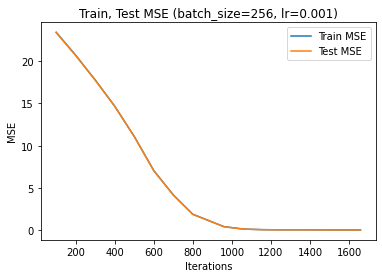

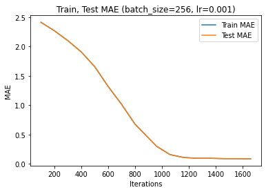

```
Final Train MSE: 0.047579973301988966
Final Train MAE: 0.08463756074296667
Final Test MSE: 0.04777299089634672
Final Test MAE: 0.08515278836514087
Val MSE: 0.04433126145220818
Val MAE: 0.08213776223202969
```

```python
show_plots(losses, loss_iters, metrics_iters, train_mae, train_mse, test_mae, test_mse, val_mse, val_mae)
```

##### Среднее по временной компоненте

```python
class SalaryPredictor(nn.Module):
    def __init__(self, n_tokens=len(tokens), n_cat_features=len(categorical_vectorizer.vocabulary_), hid_size=8):
        super().__init__()
        self.title_input_len = len(make_batch(data_train[:BATCH_SIZE])['Title'][0])
        self.description_input_len = len(make_batch(data_train[:BATCH_SIZE])['FullDescription'][0])
        self.embedder = nn.Embedding(n_tokens, hid_size, padding_idx = 1)
        self.title_encoder = nn.Sequential(
            nn.Conv1d(hid_size, hid_size*2, kernel_size=2),
            nn.MaxPool1d(2),
            nn.Conv1d(hid_size*2, hid_size, kernel_size=1),
            nn.BatchNorm1d(hid_size),
            nn.ReLU(),
            nn.Dropout(p=0.25)
        )
        self.title_pooling = nn.AvgPool1d(hid_size, count_include_pad = False)
        self.description_encoder = nn.Sequential(
            nn.Conv1d(hid_size, hid_size*2, kernel_size=2),
            nn.MaxPool1d(2),
            nn.Conv1d(hid_size*2, hid_size, kernel_size=1),
            nn.BatchNorm1d(hid_size),
            nn.ReLU(),
            nn.Dropout(p=0.25)
        )
        self.description_pooling = nn.AvgPool1d(hid_size, count_include_pad = False)
        self.categorical_encoder = nn.Sequential(
            nn.Linear(n_cat_features, hid_size * 4),
            nn.ReLU(),
            nn.Linear(hid_size * 4, hid_size * 2),
            nn.BatchNorm1d(hid_size * 2),
            nn.ReLU(),
            nn.Linear(hid_size * 2, hid_size),
            nn.BatchNorm1d(hid_size),
            nn.ReLU()
        )
        self.final_predictor_in = 34
        self.final_predictor = nn.Sequential(
            nn.Linear(self.final_predictor_in, hid_size * 2),
            nn.BatchNorm1d(hid_size * 2),
            nn.ReLU(),
            nn.Linear(hid_size * 2, hid_size),
            nn.BatchNorm1d(hid_size),
            nn.ReLU(),
            nn.Linear(hid_size, 1)
        )

    def forward(self, batch):
        # print('batch[Title]', batch['Title'])
        title_embeddings = self.embedder(batch['Title']).permute(0, 2, 1)
        title_features = self.title_encoder(title_embeddings).permute(0, 2, 1)
        title_pooling = self.title_pooling(title_features).squeeze()

        description_embeddings = self.embedder(batch['FullDescription']).permute(0, 2, 1)
        description_features = self.description_encoder(description_embeddings).permute(0, 2, 1)
        description_pooling = self.description_pooling(description_features).squeeze()

        categorical_features = self.categorical_encoder(batch['Categorical'])

        features = torch.cat(
            [title_pooling, description_pooling, categorical_features], dim=1)
        self.final_predictor_in = len(features[1])
        return self.final_predictor(features).squeeze()
```

```python
model = SalaryPredictor().to(DEVICE)
criterion = nn.MSELoss(reduction='mean')
optimizer = torch.optim.Adam(model.parameters(), lr=1e-3)

losses, loss_iters, metrics_iters, train_mae, train_mse, test_mae, test_mse = train(model, criterion, optimizer)
```

```
epoch: 0
```

```
train results:
Loss: 99.45957
Mean square error: 24.83588
Mean absolute error: 2.48846
test results:
Loss: 98.56546
Mean square error: 24.80873
Mean absolute error: 2.48716
train results:
Loss: 88.56326
Mean square error: 22.22861
Mean absolute error: 2.35374
test results:
Loss: 88.96902
Mean square error: 22.19435
Mean absolute error: 2.35196
train results:
Loss: 78.35274
Mean square error: 19.70689
Mean absolute error: 2.21483
test results:
Loss: 79.38851
Mean square error: 19.67525
Mean absolute error: 2.21309
train results:
Loss: 66.18346
Mean square error: 16.76551
Mean absolute error: 2.04072
test results:
Loss: 67.04262
Mean square error: 16.74894
Mean absolute error: 2.03968
train results:
Loss: 53.87878
Mean square error: 13.56848
Mean absolute error: 1.83249
test results:
Loss: 53.90135
Mean square error: 13.55706
Mean absolute error: 1.83188
```

[output cut: 10 more lines]

```
Mean square error: 6.95318
Mean absolute error: 1.30194
test results:
Loss: 28.28438
Mean square error: 6.96527
Mean absolute error: 1.30287
train results:
Loss: 16.54182
Mean square error: 4.20682
Mean absolute error: 1.00636
test results:
Loss: 17.34359
Mean square error: 4.20129
Mean absolute error: 1.00551
epoch: 1
```

```
train results:
Loss: 5.71431
Mean square error: 1.45348
Mean absolute error: 0.58700
test results:
Loss: 6.01425
Mean square error: 1.45212
Mean absolute error: 0.58651
train results:
Loss: 2.60891
Mean square error: 0.67085
Mean absolute error: 0.39075
test results:
Loss: 2.71262
Mean square error: 0.66677
Mean absolute error: 0.38949
train results:
Loss: 0.99911
Mean square error: 0.26234
Mean absolute error: 0.23330
test results:
Loss: 1.03121
Mean square error: 0.25859
Mean absolute error: 0.23148
train results:
Loss: 0.50212
Mean square error: 0.12920
Mean absolute error: 0.15141
test results:
Loss: 0.53600
Mean square error: 0.12792
Mean absolute error: 0.15050
train results:
Loss: 0.22555
Mean square error: 0.05707
Mean absolute error: 0.09474
test results:
Loss: 0.22291
Mean square error: 0.05614
Mean absolute error: 0.09380
```

[output cut: 9 more lines]

```
Loss: 0.15221
Mean square error: 0.04044
Mean absolute error: 0.07799
test results:
Loss: 0.19708
Mean square error: 0.04094
Mean absolute error: 0.07832
train results:
Loss: 0.14111
Mean square error: 0.03632
Mean absolute error: 0.07362
test results:
Loss: 0.15283
Mean square error: 0.03640
Mean absolute error: 0.07371
```

```python
val_mse, val_mae = print_metrics(model, data_val, name='val', batch_size=BATCH_SIZE, device=DEVICE)
```

```
val results:
Loss: 0.16407
Mean square error: 0.03507
Mean absolute error: 0.07167
```

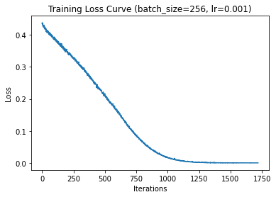

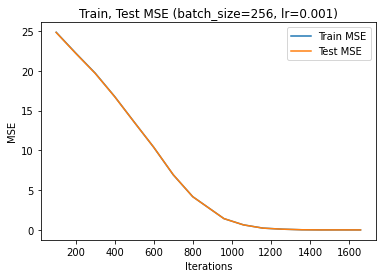

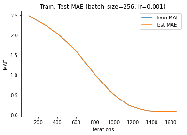

```
Final Train MSE: 0.036320589958353244
Final Train MAE: 0.07362470221012196
Final Test MSE: 0.03639944817157502
Final Test MAE: 0.07371454035982172
Val MSE: 0.03506709413325533
Val MAE: 0.07167499116126527
```

```python
show_plots(losses, loss_iters, metrics_iters, train_mae, train_mse, test_mae, test_mse, val_mse, val_mae)
```

Что было сделано:

- поменяны местами последние две оси входа в pooling слой, чтобы в одном векторе фич(слове) уместились основные признаки предложения
- в nn.Embedding был применен параметр, зануляющий значения, соответствующие PAD символам. Затем эти нули исключались из подсчета из-за параметра count_include_pad = False в слое AvgPool1d

#### 3. Используем предобученные эмбединги

```python
import gensim
import gensim.downloader as api
from gensim.models.word2vec import Word2Vec

text8_vectors = api.load('text8') # загружем текстовый корпус
model = Word2Vec(text8_vectors) # обучаем модель
weights = model.wv.vectors # сохраняем веса
emb = nn.Embedding.from_pretrained(torch.FloatTensor(weights)) # получаем эмбединги
```

```
[==================================================] 100.0% 31.6/31.6MB downloaded
```

##### Тест с замороженными весами

```python
class SalaryPredictor(nn.Module):
    def __init__(self, n_tokens=len(tokens), n_cat_features=len(categorical_vectorizer.vocabulary_), hid_size=100):
        super().__init__()
        self.embedder = nn.Embedding.from_pretrained(torch.FloatTensor(weights))
        self.title_encoder = nn.Sequential(
            nn.Conv1d(hid_size, hid_size, kernel_size=2),
            nn.MaxPool1d(2),
            nn.Conv1d(hid_size, hid_size, kernel_size=1),
            nn.BatchNorm1d(hid_size),
            nn.ReLU(),
            nn.Dropout(p=0.25),
            nn.AdaptiveMaxPool1d(output_size=1)
        )
        self.description_encoder = nn.Sequential(
            nn.Conv1d(hid_size, hid_size, kernel_size=2),
            nn.MaxPool1d(2),
            nn.Conv1d(hid_size, hid_size, kernel_size=1),
            nn.BatchNorm1d(hid_size),
            nn.ReLU(),
            nn.Dropout(p=0.25),
            nn.AdaptiveMaxPool1d(output_size=1)
        )

        self.categorical_encoder = nn.Sequential(
            nn.Linear(n_cat_features, hid_size * 4),
            nn.ReLU(),
            nn.Linear(hid_size * 4, hid_size * 2),
            nn.BatchNorm1d(hid_size * 2),
            nn.ReLU(),
            nn.Linear(hid_size * 2, hid_size),
            nn.BatchNorm1d(hid_size),
            nn.ReLU()
        )
        self.final_predictor = nn.Sequential(
            nn.Linear(hid_size * 3, hid_size * 2),
            nn.BatchNorm1d(hid_size * 2),
            nn.ReLU(),
            nn.Linear(hid_size * 2, hid_size),
            nn.BatchNorm1d(hid_size),
            nn.ReLU()
        )
        self.classifier = nn.Linear(hid_size, 1)

    def forward(self, batch):
        title_embeddings = self.embedder(batch['Title']).permute(0, 2, 1)
        title_features = self.title_encoder(title_embeddings).squeeze()

        description_embeddings = self.embedder(batch['FullDescription']).permute(0, 2, 1)
        description_features = self.description_encoder(description_embeddings).squeeze()

        categorical_features = self.categorical_encoder(batch['Categorical'])

        features = torch.cat(
            [title_features, description_features, categorical_features], dim=1)

        return self.classifier(self.final_predictor(features)).squeeze()
```

```python
model = SalaryPredictor().to(DEVICE)
criterion = nn.MSELoss(reduction='mean')
optimizer = torch.optim.Adam(model.parameters(), lr=1e-3)

losses, loss_iters, metrics_iters, train_mae, train_mse, test_mae, test_mse = train(model, criterion, optimizer)
```

```
epoch: 0
```

```
train results:
Loss: 23.29182
Mean square error: 5.82872
Mean absolute error: 1.19732
test results:
Loss: 22.60266
Mean square error: 5.81478
Mean absolute error: 1.19588
train results:
Loss: 1.46655
Mean square error: 0.36916
Mean absolute error: 0.26735
test results:
Loss: 1.38788
Mean square error: 0.36025
Mean absolute error: 0.26395
train results:
Loss: 0.25805
Mean square error: 0.06621
Mean absolute error: 0.10008
test results:
Loss: 0.26046
Mean square error: 0.06650
Mean absolute error: 0.10025
train results:
Loss: 0.16380
Mean square error: 0.04786
Mean absolute error: 0.08633
test results:
Loss: 0.16956
Mean square error: 0.04754
Mean absolute error: 0.08604
train results:
Loss: 0.21285
Mean square error: 0.05310
Mean absolute error: 0.09238
test results:
Loss: 0.23483
Mean square error: 0.05483
Mean absolute error: 0.09385
```

[output cut: 10 more lines]

```
Mean square error: 0.04614
Mean absolute error: 0.08425
test results:
Loss: 0.17756
Mean square error: 0.04664
Mean absolute error: 0.08457
train results:
Loss: 0.13081
Mean square error: 0.03340
Mean absolute error: 0.07098
test results:
Loss: 0.14330
Mean square error: 0.03467
Mean absolute error: 0.07234
epoch: 1
```

```
train results:
Loss: 0.12899
Mean square error: 0.03252
Mean absolute error: 0.06955
test results:
Loss: 0.13798
Mean square error: 0.03438
Mean absolute error: 0.07131
train results:
Loss: 0.11759
Mean square error: 0.03019
Mean absolute error: 0.06651
test results:
Loss: 0.11986
Mean square error: 0.03168
Mean absolute error: 0.06831
train results:
Loss: 0.11593
Mean square error: 0.02861
Mean absolute error: 0.06454
test results:
Loss: 0.12190
Mean square error: 0.03043
Mean absolute error: 0.06672
train results:
Loss: 0.12407
Mean square error: 0.02925
Mean absolute error: 0.06496
test results:
Loss: 0.11590
Mean square error: 0.03130
Mean absolute error: 0.06743
train results:
Loss: 0.12597
Mean square error: 0.03355
Mean absolute error: 0.07130
test results:
Loss: 0.13385
Mean square error: 0.03443
Mean absolute error: 0.07200
```

[output cut: 9 more lines]

```
Loss: 0.11534
Mean square error: 0.02796
Mean absolute error: 0.06375
test results:
Loss: 0.11412
Mean square error: 0.02978
Mean absolute error: 0.06586
train results:
Loss: 0.10654
Mean square error: 0.02694
Mean absolute error: 0.06280
test results:
Loss: 0.11426
Mean square error: 0.02934
Mean absolute error: 0.06559
```

```python
val_mse, val_mae = print_metrics(model, data_val, name='val', batch_size=BATCH_SIZE, device=DEVICE)
```

```
val results:
Loss: 0.13743
Mean square error: 0.02870
Mean absolute error: 0.06429
```

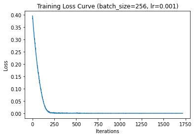

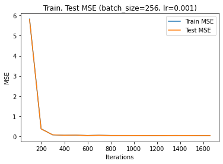

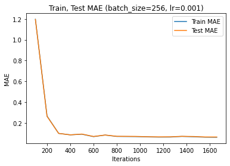

```
Final Train MSE: 0.026944561207548103
Final Train MAE: 0.06280231475830078
Final Test MSE: 0.029340523354550625
Final Test MAE: 0.06559388180996509
Val MSE: 0.028703108746954736
Val MAE: 0.06428940245445738
```

```python
show_plots(losses, loss_iters, metrics_iters, train_mae, train_mse, test_mae, test_mse, val_mse, val_mae)
```

##### Тест с размороженными весами

```python
class SalaryPredictor(nn.Module):
    def __init__(self, n_tokens=len(tokens), n_cat_features=len(categorical_vectorizer.vocabulary_), hid_size=100):
        super().__init__()
        self.embedder = nn.Embedding.from_pretrained(torch.FloatTensor(weights), freeze = False)
        self.title_encoder = nn.Sequential(
            nn.Conv1d(hid_size, hid_size, kernel_size=2),
            nn.MaxPool1d(2),
            nn.Conv1d(hid_size, hid_size, kernel_size=1),
            nn.BatchNorm1d(hid_size),
            nn.ReLU(),
            nn.Dropout(p=0.25),
            nn.AdaptiveMaxPool1d(output_size=1)
        )
        self.description_encoder = nn.Sequential(
            nn.Conv1d(hid_size, hid_size, kernel_size=2),
            nn.MaxPool1d(2),
            nn.Conv1d(hid_size, hid_size, kernel_size=1),
            nn.BatchNorm1d(hid_size),
            nn.ReLU(),
            nn.Dropout(p=0.25),
            nn.AdaptiveMaxPool1d(output_size=1)
        )

        self.categorical_encoder = nn.Sequential(
            nn.Linear(n_cat_features, hid_size * 4),
            nn.ReLU(),
            nn.Linear(hid_size * 4, hid_size * 2),
            nn.BatchNorm1d(hid_size * 2),
            nn.ReLU(),
            nn.Linear(hid_size * 2, hid_size),
            nn.BatchNorm1d(hid_size),
            nn.ReLU()
        )
        self.final_predictor = nn.Sequential(
            nn.Linear(hid_size * 3, hid_size * 2),
            nn.BatchNorm1d(hid_size * 2),
            nn.ReLU(),
            nn.Linear(hid_size * 2, hid_size),
            nn.BatchNorm1d(hid_size),
            nn.ReLU()
        )
        self.classifier = nn.Linear(hid_size, 1)

    def forward(self, batch):
        title_embeddings = self.embedder(batch['Title']).permute(0, 2, 1)
        title_features = self.title_encoder(title_embeddings).squeeze()

        description_embeddings = self.embedder(batch['FullDescription']).permute(0, 2, 1)
        description_features = self.description_encoder(description_embeddings).squeeze()

        categorical_features = self.categorical_encoder(batch['Categorical'])

        features = torch.cat(
            [title_features, description_features, categorical_features], dim=1)

        return self.classifier(self.final_predictor(features)).squeeze()
```

```python
model = SalaryPredictor().to(DEVICE)
criterion = nn.MSELoss(reduction='mean')
optimizer = torch.optim.Adam(model.parameters(), lr=1e-3)

losses, loss_iters, metrics_iters, train_mae, train_mse, test_mae, test_mse = train(model, criterion, optimizer)
```

```
epoch: 0
```

```
train results:
Loss: 27.31619
Mean square error: 6.79463
Mean absolute error: 1.29244
test results:
Loss: 26.73298
Mean square error: 6.79570
Mean absolute error: 1.29241
train results:
Loss: 1.18557
Mean square error: 0.28557
Mean absolute error: 0.23705
test results:
Loss: 1.06840
Mean square error: 0.28348
Mean absolute error: 0.23613
train results:
Loss: 0.25802
Mean square error: 0.07179
Mean absolute error: 0.10829
test results:
Loss: 0.26271
Mean square error: 0.07092
Mean absolute error: 0.10811
train results:
Loss: 0.19480
Mean square error: 0.05456
Mean absolute error: 0.09197
test results:
Loss: 0.19227
Mean square error: 0.05414
Mean absolute error: 0.09173
train results:
Loss: 0.16507
Mean square error: 0.04029
Mean absolute error: 0.07922
test results:
Loss: 0.16340
Mean square error: 0.04096
Mean absolute error: 0.07978
```

[output cut: 10 more lines]

```
Mean square error: 0.03154
Mean absolute error: 0.06852
test results:
Loss: 0.11133
Mean square error: 0.03155
Mean absolute error: 0.06845
train results:
Loss: 0.09718
Mean square error: 0.02764
Mean absolute error: 0.06328
test results:
Loss: 0.09973
Mean square error: 0.02858
Mean absolute error: 0.06441
epoch: 1
```

```
train results:
Loss: 0.09922
Mean square error: 0.02900
Mean absolute error: 0.06574
test results:
Loss: 0.11196
Mean square error: 0.02982
Mean absolute error: 0.06663
train results:
Loss: 0.09817
Mean square error: 0.02638
Mean absolute error: 0.06224
test results:
Loss: 0.10689
Mean square error: 0.02744
Mean absolute error: 0.06369
train results:
Loss: 0.09003
Mean square error: 0.02511
Mean absolute error: 0.06038
test results:
Loss: 0.09592
Mean square error: 0.02609
Mean absolute error: 0.06141
train results:
Loss: 0.08607
Mean square error: 0.02226
Mean absolute error: 0.05627
test results:
Loss: 0.09337
Mean square error: 0.02357
Mean absolute error: 0.05781
train results:
Loss: 0.11183
Mean square error: 0.02980
Mean absolute error: 0.06764
test results:
Loss: 0.12515
Mean square error: 0.03088
Mean absolute error: 0.06850
```

[output cut: 9 more lines]

```
Loss: 0.07941
Mean square error: 0.02198
Mean absolute error: 0.05576
test results:
Loss: 0.08827
Mean square error: 0.02315
Mean absolute error: 0.05735
train results:
Loss: 0.06882
Mean square error: 0.02074
Mean absolute error: 0.05410
test results:
Loss: 0.09146
Mean square error: 0.02245
Mean absolute error: 0.05646
```

```python
val_mse, val_mae = print_metrics(model, data_val, name='val', batch_size=BATCH_SIZE, device=DEVICE)
```

```
val results:
Loss: 0.10109
Mean square error: 0.02273
Mean absolute error: 0.05679
```

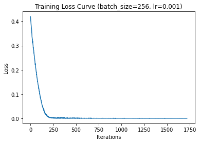

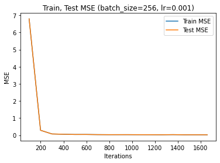

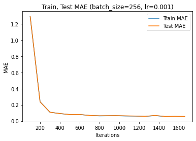

```
Final Train MSE: 0.02074446069433334
Final Train MAE: 0.05410179686039052
Final Test MSE: 0.02244532361943671
Final Test MAE: 0.05646239950301799
Val MSE: 0.022732227406603224
Val MAE: 0.05679403467381254
```

```python
show_plots(losses, loss_iters, metrics_iters, train_mae, train_mse, test_mae, test_mse, val_mse, val_mae)
```

```python
torch.save(model.state_dict(), '/content/drive/MyDrive/ИАД_ЛАБ3/best_model')
```

#### 4. Заменим сверточные слои на рекуррентные

##### Однонаправленная

```python
class SalaryPredictor(nn.Module):
    def __init__(self, n_tokens=len(tokens), n_cat_features=len(categorical_vectorizer.vocabulary_), hid_size=256, n_layers=2):
        super().__init__()
        self.title_input_len = len(make_batch(data_train[:BATCH_SIZE])['Title'][0])
        self.description_input_len = len(make_batch(data_train[:BATCH_SIZE])['FullDescription'][0])

        self.hid_size = hid_size
        self.n_layers = n_layers

        self.embedder = nn.Embedding.from_pretrained(torch.FloatTensor(weights))

        self.title_encoder_LSTM = nn.LSTM(self.title_input_len, hid_size, n_layers, dropout=0.5, batch_first=True)

        self.title_encoder = nn.Sequential(
            nn.Dropout(p=0.25)
        )

        self.description_encoder_LSTM = nn.LSTM(self.description_input_len, hid_size, n_layers, dropout=0.5, batch_first=True)

        self.description_encoder = nn.Sequential(
            nn.Dropout(p=0.25)
        )

        self.categorical_encoder = nn.Sequential(
            nn.Linear(n_cat_features, hid_size * 4),
            nn.ReLU(),
            nn.Linear(hid_size * 4, hid_size * 2),
            nn.BatchNorm1d(hid_size * 2),
            nn.ReLU(),
            nn.Linear(hid_size * 2, hid_size),
            nn.BatchNorm1d(hid_size),
            nn.ReLU()
        )
        self.final_predictor = nn.Sequential(
            nn.Linear(hid_size * 3, hid_size * 2),
            nn.BatchNorm1d(hid_size * 2),
            nn.ReLU(),
            nn.Linear(hid_size * 2, hid_size),
            nn.BatchNorm1d(hid_size),
            nn.ReLU(),
            nn.Linear(hid_size, 1)
        )

    def init_hidden(self, batch_size):
        hidden = (torch.zeros(self.n_layers, batch_size, self.hid_size).cuda(),
                  torch.zeros(self.n_layers, batch_size, self.hid_size).cuda())

        return hidden

    def forward(self, batch, hidden):
        title_embeddings = self.embedder(batch['Title']).permute(0, 2, 1)
        title_out, title_hidden = self.title_encoder_LSTM(title_embeddings, hidden)
        title_features = self.title_encoder(title_out[:, -1, :])

        description_embeddings = self.embedder(batch['FullDescription']).permute(0, 2, 1)
        description_out, description_hidden = self.description_encoder_LSTM(description_embeddings, hidden)
        description_features = self.description_encoder(description_out[:, -1, :])

        categorical_features = self.categorical_encoder(batch['Categorical'])

        features = torch.cat(
            [title_features, description_features, categorical_features], dim=1)

        return self.final_predictor(features).squeeze()
```

```python
model = SalaryPredictor().to(DEVICE)
criterion = nn.MSELoss(reduction='mean')
optimizer = torch.optim.Adam(model.parameters(), lr=1e-3)

losses, loss_iters, metrics_iters, train_mae, train_mse, test_mae, test_mse = train(model, criterion, optimizer, has_reccurent = True)
```

```
epoch: 0
```

```
train results:
Loss: 1.98344
Mean square error: 0.52832
Mean absolute error: 0.33776
test results:
Loss: 2.08529
Mean square error: 0.52359
Mean absolute error: 0.33657
train results:
Loss: 0.20781
Mean square error: 0.05906
Mean absolute error: 0.09522
test results:
Loss: 0.21714
Mean square error: 0.05790
Mean absolute error: 0.09410
train results:
Loss: 0.18033
Mean square error: 0.04460
Mean absolute error: 0.08231
test results:
Loss: 0.15258
Mean square error: 0.04321
Mean absolute error: 0.08103
train results:
Loss: 0.14996
Mean square error: 0.04020
Mean absolute error: 0.07806
test results:
Loss: 0.15676
Mean square error: 0.04054
Mean absolute error: 0.07835
train results:
Loss: 0.16406
Mean square error: 0.04262
Mean absolute error: 0.08120
test results:
Loss: 0.16521
Mean square error: 0.04362
Mean absolute error: 0.08233
```

[output cut: 10 more lines]

```
Mean square error: 0.03394
Mean absolute error: 0.07094
test results:
Loss: 0.14196
Mean square error: 0.03496
Mean absolute error: 0.07241
train results:
Loss: 0.12444
Mean square error: 0.03308
Mean absolute error: 0.06930
test results:
Loss: 0.11912
Mean square error: 0.03336
Mean absolute error: 0.06939
epoch: 1
```

```
train results:
Loss: 0.11882
Mean square error: 0.03084
Mean absolute error: 0.06718
test results:
Loss: 0.12144
Mean square error: 0.03167
Mean absolute error: 0.06813
train results:
Loss: 0.11897
Mean square error: 0.03015
Mean absolute error: 0.06654
test results:
Loss: 0.11964
Mean square error: 0.03165
Mean absolute error: 0.06826
train results:
Loss: 0.14043
Mean square error: 0.03401
Mean absolute error: 0.07188
test results:
Loss: 0.13421
Mean square error: 0.03565
Mean absolute error: 0.07380
train results:
Loss: 0.12037
Mean square error: 0.03147
Mean absolute error: 0.06766
test results:
Loss: 0.12093
Mean square error: 0.03210
Mean absolute error: 0.06834
train results:
Loss: 0.12037
Mean square error: 0.03002
Mean absolute error: 0.06590
test results:
Loss: 0.12191
Mean square error: 0.03225
Mean absolute error: 0.06853
```

[output cut: 9 more lines]

```
Loss: 0.11473
Mean square error: 0.03026
Mean absolute error: 0.06710
test results:
Loss: 0.12070
Mean square error: 0.03246
Mean absolute error: 0.06955
train results:
Loss: 0.10548
Mean square error: 0.02970
Mean absolute error: 0.06578
test results:
Loss: 0.11544
Mean square error: 0.03127
Mean absolute error: 0.06777
```

```python
val_mse, val_mae = print_metrics(model, data_val, name='val', batch_size=BATCH_SIZE, h=model.init_hidden(BATCH_SIZE), device=DEVICE)
```

```
val results:
Loss: 0.15089
Mean square error: 0.03246
Mean absolute error: 0.06918
```

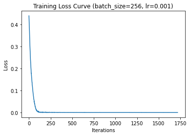

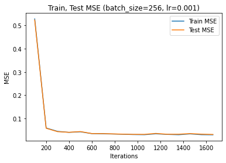

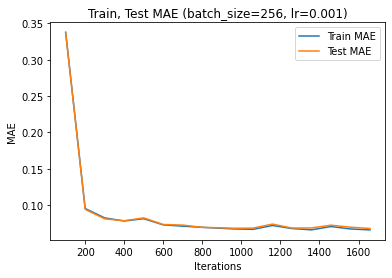

```
Final Train MSE: 0.02970205976607952
Final Train MAE: 0.06578466232786788
Final Test MSE: 0.03126845207620174
Final Test MAE: 0.06776873101579382
Val MSE: 0.03246431655072151
Val MAE: 0.0691824568078873
```

```python
show_plots(losses, loss_iters, metrics_iters, train_mae, train_mse, test_mae, test_mse, val_mse, val_mae)
```

##### Двунаправленная

```python
class SalaryPredictor(nn.Module):
    def __init__(self, n_tokens=len(tokens), n_cat_features=len(categorical_vectorizer.vocabulary_), hid_size=256, n_layers=2, bi_directional = True):
        super().__init__()
        self.title_input_len = len(make_batch(data_train[:BATCH_SIZE])['Title'][0])
        self.description_input_len = len(make_batch(data_train[:BATCH_SIZE])['FullDescription'][0])

        if bi_directional:
            self.dim = 2
        else:
            self.dim = 1

        self.hid_size = hid_size
        self.n_layers = n_layers

        self.embedder = nn.Embedding.from_pretrained(torch.FloatTensor(weights))

        self.title_encoder_LSTM = nn.LSTM(self.title_input_len, hid_size, n_layers, dropout=0.5, batch_first=True, bidirectional = True)

        self.title_encoder = nn.Sequential(
            nn.Dropout(p=0.25),
            nn.Linear(self.dim * hid_size, hid_size)
        )

        self.description_encoder_LSTM = nn.LSTM(self.description_input_len, hid_size, n_layers, dropout=0.5, batch_first=True, bidirectional = True)

        self.description_encoder = nn.Sequential(
            nn.Dropout(p=0.25),
            nn.Linear(self.dim * hid_size, hid_size)
        )


        self.categorical_encoder = nn.Sequential(
            nn.Linear(n_cat_features, hid_size * 4),
            nn.ReLU(),
            nn.Linear(hid_size * 4, hid_size * 2),
            nn.BatchNorm1d(hid_size * 2),
            nn.ReLU(),
            nn.Linear(hid_size * 2, hid_size),
            nn.BatchNorm1d(hid_size),
            nn.ReLU()
        )
        self.final_predictor = nn.Sequential(
            nn.Linear(hid_size * 3, hid_size * 2),
            nn.BatchNorm1d(hid_size * 2),
            nn.ReLU(),
            nn.Linear(hid_size * 2, hid_size),
            nn.BatchNorm1d(hid_size),
            nn.ReLU(),
            nn.Linear(hid_size, 1)
        )


    def forward(self, batch, hidden):
        title_embeddings = self.embedder(batch['Title']).permute(0, 2, 1)
        title_out, title_hidden = self.title_encoder_LSTM(title_embeddings, hidden)
        title_features = self.title_encoder(title_out[:, -1, :])

        description_embeddings = self.embedder(batch['FullDescription']).permute(0, 2, 1)
        description_out, description_hidden = self.description_encoder_LSTM(description_embeddings, hidden)
        description_features = self.description_encoder(description_out[:, -1, :])

        categorical_features = self.categorical_encoder(batch['Categorical'])

        features = torch.cat(
            [title_features, description_features, categorical_features], dim=1)

        return self.final_predictor(features).squeeze()

    def init_hidden(self, batch_size):
        hidden = (torch.zeros(self.dim * self.n_layers, batch_size, self.hid_size).cuda(),
                    torch.zeros(self.dim * self.n_layers, batch_size, self.hid_size).cuda())

        return hidden
```

```python
model = SalaryPredictor().to(DEVICE)
criterion = nn.MSELoss(reduction='mean')
optimizer = torch.optim.Adam(model.parameters(), lr=1e-3)

losses, loss_iters, metrics_iters, train_mae, train_mse, test_mae, test_mse = train(model, criterion, optimizer, has_reccurent = True)
```

```
epoch: 0
```

```
train results:
Loss: 1.08196
Mean square error: 0.28414
Mean absolute error: 0.23693
test results:
Loss: 1.16671
Mean square error: 0.28345
Mean absolute error: 0.23645
train results:
Loss: 0.60327
Mean square error: 0.13301
Mean absolute error: 0.15406
test results:
Loss: 0.56887
Mean square error: 0.13203
Mean absolute error: 0.15393
train results:
Loss: 0.14860
Mean square error: 0.04079
Mean absolute error: 0.07896
test results:
Loss: 0.17896
Mean square error: 0.04060
Mean absolute error: 0.07869
train results:
Loss: 0.16321
Mean square error: 0.04514
Mean absolute error: 0.08308
test results:
Loss: 0.17105
Mean square error: 0.04418
Mean absolute error: 0.08213
train results:
Loss: 0.13226
Mean square error: 0.03780
Mean absolute error: 0.07485
test results:
Loss: 0.14520
Mean square error: 0.03733
Mean absolute error: 0.07448
```

[output cut: 10 more lines]

```
Mean square error: 0.03581
Mean absolute error: 0.07267
test results:
Loss: 0.13445
Mean square error: 0.03541
Mean absolute error: 0.07233
train results:
Loss: 0.13133
Mean square error: 0.03618
Mean absolute error: 0.07384
test results:
Loss: 0.14540
Mean square error: 0.03652
Mean absolute error: 0.07436
epoch: 1
```

```
train results:
Loss: 0.12777
Mean square error: 0.03140
Mean absolute error: 0.06798
test results:
Loss: 0.12348
Mean square error: 0.03261
Mean absolute error: 0.06939
train results:
Loss: 0.11608
Mean square error: 0.03193
Mean absolute error: 0.06896
test results:
Loss: 0.12511
Mean square error: 0.03321
Mean absolute error: 0.07064
train results:
Loss: 0.12260
Mean square error: 0.03189
Mean absolute error: 0.06831
test results:
Loss: 0.12262
Mean square error: 0.03298
Mean absolute error: 0.06963
train results:
Loss: 0.13744
Mean square error: 0.03117
Mean absolute error: 0.06725
test results:
Loss: 0.13068
Mean square error: 0.03221
Mean absolute error: 0.06870
train results:
Loss: 0.10649
Mean square error: 0.03065
Mean absolute error: 0.06662
test results:
Loss: 0.11595
Mean square error: 0.03167
Mean absolute error: 0.06813
```

[output cut: 9 more lines]

```
Loss: 0.12810
Mean square error: 0.03114
Mean absolute error: 0.06760
test results:
Loss: 0.12001
Mean square error: 0.03265
Mean absolute error: 0.06956
train results:
Loss: 0.11619
Mean square error: 0.03117
Mean absolute error: 0.06785
test results:
Loss: 0.12541
Mean square error: 0.03302
Mean absolute error: 0.06984
```

```python
val_mse, val_mae = print_metrics(model, data_val, name='val', batch_size=BATCH_SIZE, h=model.init_hidden(BATCH_SIZE), device=DEVICE)
```

```
val results:
Loss: 0.13969
Mean square error: 0.03080
Mean absolute error: 0.06723
```

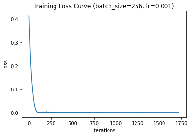

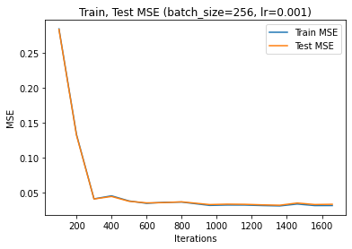

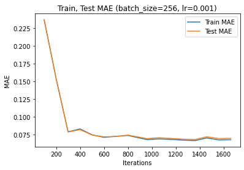

```
Final Train MSE: 0.031173224144793572
Final Train MAE: 0.0678456945622221
Final Test MSE: 0.03302368458281172
Final Test MAE: 0.06984468723865266
Val MSE: 0.030796895635888933
Val MAE: 0.06722668383983856
```

```python
show_plots(losses, loss_iters, metrics_iters, train_mae, train_mse, test_mae, test_mse, val_mse, val_mae)
```

##### Комбинируем сверточные и рекурентные слои

```python
class SalaryPredictor(nn.Module):
    def __init__(self, n_tokens=len(tokens), n_cat_features=len(categorical_vectorizer.vocabulary_), hid_size=256, n_layers=2):
        super().__init__()
        self.title_input_len = len(make_batch(data_train[:BATCH_SIZE])['Title'][0])
        self.description_input_len = len(make_batch(data_train[:BATCH_SIZE])['FullDescription'][0])
        self.weights_len = len(weights[0])

        self.hid_size = hid_size
        self.n_layers = n_layers

        self.embedder = nn.Embedding.from_pretrained(torch.FloatTensor(weights))

        self.title_encoder_CNN = nn.Sequential(
            nn.Conv1d(self.weights_len, 2*hid_size, kernel_size=2),
            nn.MaxPool1d(2),
            nn.Conv1d(hid_size*2, hid_size, kernel_size=1),
        )

        self.title_encoder_LSTM = nn.LSTM(13, hid_size, n_layers, dropout=0.5, batch_first=True)

        self.title_encoder = nn.Sequential(
            nn.Dropout(p=0.25)
        )

        self.description_encoder_CNN = nn.Sequential(
            nn.Conv1d(self.weights_len, 2*hid_size, kernel_size=2),
            nn.MaxPool1d(2),
            nn.Conv1d(hid_size*2, hid_size, kernel_size=1),
        )

        self.description_encoder_LSTM = nn.LSTM(13, hid_size, n_layers, dropout=0.5, batch_first=True)

        self.description_encoder = nn.Sequential(
            nn.Dropout(p=0.25)
        )

        self.categorical_encoder = nn.Sequential(
            nn.Linear(n_cat_features, hid_size * 4),
            nn.ReLU(),
            nn.Linear(hid_size * 4, hid_size * 2),
            nn.BatchNorm1d(hid_size * 2),
            nn.ReLU(),
            nn.Linear(hid_size * 2, hid_size),
            nn.BatchNorm1d(hid_size),
            nn.ReLU()
        )
        self.final_predictor = nn.Sequential(
            nn.Linear(hid_size * 3, hid_size * 2),
            nn.BatchNorm1d(hid_size * 2),
            nn.ReLU(),
            nn.Linear(hid_size * 2, hid_size),
            nn.BatchNorm1d(hid_size),
            nn.ReLU(),
            nn.Linear(hid_size, 1)
        )


    def forward(self, batch, hidden):
        title_embeddings = self.embedder(batch['Title']).permute(0, 2, 1)
        title_convolution = self.title_encoder_CNN(title_embeddings)
        title_out, title_hidden = self.title_encoder_LSTM(title_convolution, hidden)
        title_features = self.title_encoder(title_out[:, -1, :])

        description_embeddings = self.embedder(batch['FullDescription']).permute(0, 2, 1)
        description_convolution = self.description_encoder_CNN(description_embeddings)
        description_out, description_hidden = self.description_encoder_LSTM(description_convolution, hidden)
        description_features = self.description_encoder(description_out[:, -1, :])

        categorical_features = self.categorical_encoder(batch['Categorical'])

        features = torch.cat(
            [title_features, description_features, categorical_features], dim=1)

        return self.final_predictor(features).squeeze()

    def init_hidden(self, batch_size):
        hidden = (torch.zeros(self.n_layers, batch_size, self.hid_size).cuda(),
                  torch.zeros(self.n_layers, batch_size, self.hid_size).cuda())

        return hidden
```

```python
model = SalaryPredictor().to(DEVICE)
criterion = nn.MSELoss(reduction='mean')
optimizer = torch.optim.Adam(model.parameters(), lr=1e-3)

losses, loss_iters, metrics_iters, train_mae, train_mse, test_mae, test_mse = train(model, criterion, optimizer, has_reccurent = True)
```

```
epoch: 0
```

```
train results:
Loss: 1.89707
Mean square error: 0.47800
Mean absolute error: 0.31451
test results:
Loss: 1.87877
Mean square error: 0.47599
Mean absolute error: 0.31414
train results:
Loss: 0.26237
Mean square error: 0.06996
Mean absolute error: 0.10751
test results:
Loss: 0.22969
Mean square error: 0.06878
Mean absolute error: 0.10604
train results:
Loss: 0.16611
Mean square error: 0.04397
Mean absolute error: 0.08217
test results:
Loss: 0.16779
Mean square error: 0.04329
Mean absolute error: 0.08099
train results:
Loss: 0.10760
Mean square error: 0.03039
Mean absolute error: 0.06669
test results:
Loss: 0.10189
Mean square error: 0.03018
Mean absolute error: 0.06617
train results:
Loss: 0.13507
Mean square error: 0.03447
Mean absolute error: 0.07183
test results:
Loss: 0.13695
Mean square error: 0.03504
Mean absolute error: 0.07267
```

[output cut: 10 more lines]

```
Mean square error: 0.02943
Mean absolute error: 0.06505
test results:
Loss: 0.10971
Mean square error: 0.03018
Mean absolute error: 0.06598
train results:
Loss: 0.09945
Mean square error: 0.02811
Mean absolute error: 0.06376
test results:
Loss: 0.10779
Mean square error: 0.02852
Mean absolute error: 0.06425
epoch: 1
```

```
train results:
Loss: 0.09690
Mean square error: 0.02671
Mean absolute error: 0.06231
test results:
Loss: 0.11441
Mean square error: 0.02765
Mean absolute error: 0.06329
train results:
Loss: 0.09806
Mean square error: 0.02579
Mean absolute error: 0.06095
test results:
Loss: 0.10426
Mean square error: 0.02707
Mean absolute error: 0.06266
train results:
Loss: 0.09478
Mean square error: 0.02602
Mean absolute error: 0.06086
test results:
Loss: 0.10288
Mean square error: 0.02744
Mean absolute error: 0.06261
train results:
Loss: 0.08557
Mean square error: 0.02544
Mean absolute error: 0.06017
test results:
Loss: 0.09763
Mean square error: 0.02666
Mean absolute error: 0.06170
train results:
Loss: 0.08197
Mean square error: 0.02403
Mean absolute error: 0.05817
test results:
Loss: 0.09865
Mean square error: 0.02527
Mean absolute error: 0.05973
```

[output cut: 9 more lines]

```
Loss: 0.08607
Mean square error: 0.02554
Mean absolute error: 0.06051
test results:
Loss: 0.10062
Mean square error: 0.02708
Mean absolute error: 0.06222
train results:
Loss: 0.07699
Mean square error: 0.02416
Mean absolute error: 0.05811
test results:
Loss: 0.08919
Mean square error: 0.02494
Mean absolute error: 0.05925
```

```python
val_mse, val_mae = print_metrics(model, data_val, name='val', batch_size=BATCH_SIZE, h=model.init_hidden(BATCH_SIZE), device=DEVICE)
```

```
val results:
Loss: 0.12030
Mean square error: 0.02519
Mean absolute error: 0.05994
```

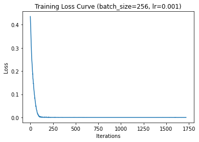

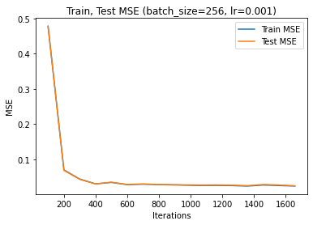

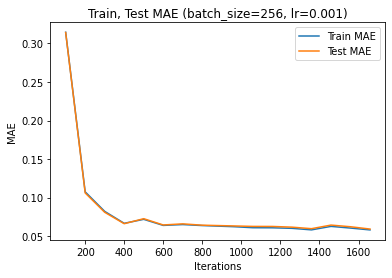

```
Final Train MSE: 0.024158759320035895
Final Train MAE: 0.05811402645516903
Final Test MSE: 0.024944262301668206
Final Test MAE: 0.059245890759407206
Val MSE: 0.02518937942829538
Val MAE: 0.059942007064819336
```

```python
show_plots(losses, loss_iters, metrics_iters, train_mae, train_mse, test_mae, test_mse, val_mse, val_mae)
```

- Как показал эксперимент, моделям с LSTM требуется меньшее количество итераций для схождения, но сами итерации длятся намного дольше.
- Двунаправленная модель обучается дольше, и привела к более низким результатам, чем однонаправленная сеть
- Так как значения метрик получились довольно низкими (почти такие же, как у лучшей модели), считаю, что данное сочетание является удачным.

#### 5. Вытащим признаки из нейронной сети и используем их в ансамбле деревьев решений

```python
!pip install -Uq 'lightgbm>=3.3.1'
```

```
     |████████████████████████████████| 2.0 MB 4.2 MB/s
```

```python
import pickle
import lightgbm as lgb
```

```python
class SalaryPredictor(nn.Module):
    def __init__(self, n_tokens=len(tokens), n_cat_features=len(categorical_vectorizer.vocabulary_), hid_size=100):
        super().__init__()
        self.embedder = nn.Embedding.from_pretrained(torch.FloatTensor(weights), freeze = False)
        self.title_encoder = nn.Sequential(
            nn.Conv1d(hid_size, hid_size, kernel_size=2),
            nn.MaxPool1d(2),
            nn.Conv1d(hid_size, hid_size, kernel_size=1),
            nn.BatchNorm1d(hid_size),
            nn.ReLU(),
            nn.Dropout(p=0.25),
            nn.AdaptiveMaxPool1d(output_size=1)
        )
        self.description_encoder = nn.Sequential(
            nn.Conv1d(hid_size, hid_size, kernel_size=2),
            nn.MaxPool1d(2),
            nn.Conv1d(hid_size, hid_size, kernel_size=1),
            nn.BatchNorm1d(hid_size),
            nn.ReLU(),
            nn.Dropout(p=0.25),
            nn.AdaptiveMaxPool1d(output_size=1)
        )

        self.categorical_encoder = nn.Sequential(
            nn.Linear(n_cat_features, hid_size * 4),
            nn.ReLU(),
            nn.Linear(hid_size * 4, hid_size * 2),
            nn.BatchNorm1d(hid_size * 2),
            nn.ReLU(),
            nn.Linear(hid_size * 2, hid_size),
            nn.BatchNorm1d(hid_size),
            nn.ReLU()
        )
        self.final_predictor = nn.Sequential(
            nn.Linear(hid_size * 3, hid_size * 2),
            nn.BatchNorm1d(hid_size * 2),
            nn.ReLU(),
            nn.Linear(hid_size * 2, hid_size),
            nn.BatchNorm1d(hid_size),
            nn.ReLU()
        )
        self.classifier = nn.Linear(hid_size, 1)

    def forward(self, batch):
        title_embeddings = self.embedder(batch['Title']).permute(0, 2, 1)
        title_features = self.title_encoder(title_embeddings).squeeze()

        description_embeddings = self.embedder(batch['FullDescription']).permute(0, 2, 1)
        description_features = self.description_encoder(description_embeddings).squeeze()

        categorical_features = self.categorical_encoder(batch['Categorical'])

        features = torch.cat(
            [title_features, description_features, categorical_features], dim=1)

        return self.classifier(self.final_predictor(features)).squeeze()
```

```python
model = SalaryPredictor().to(DEVICE)
model.load_state_dict(torch.load('/content/drive/MyDrive/ИАД_ЛАБ3/best_model'))
```

```
<All keys matched successfully>
```

```python
model
```

```
SalaryPredictor(
  (embedder): Embedding(71290, 100)
  (title_encoder): Sequential(
    (0): Conv1d(100, 100, kernel_size=(2,), stride=(1,))
    (1): MaxPool1d(kernel_size=2, stride=2, padding=0, dilation=1, ceil_mode=False)
    (2): Conv1d(100, 100, kernel_size=(1,), stride=(1,))
    (3): BatchNorm1d(100, eps=1e-05, momentum=0.1, affine=True, track_running_stats=True)
    (4): ReLU()
    (5): Dropout(p=0.25, inplace=False)
    (6): AdaptiveMaxPool1d(output_size=1)
  )
  (description_encoder): Sequential(
    (0): Conv1d(100, 100, kernel_size=(2,), stride=(1,))
    (1): MaxPool1d(kernel_size=2, stride=2, padding=0, dilation=1, ceil_mode=False)
    (2): Conv1d(100, 100, kernel_size=(1,), stride=(1,))
    (3): BatchNorm1d(100, eps=1e-05, momentum=0.1, affine=True, track_running_stats=True)
    (4): ReLU()
    (5): Dropout(p=0.25, inplace=False)
    (6): AdaptiveMaxPool1d(output_size=1)
  )
  (categorical_encoder): Sequential(
    (0): Linear(in_features=3768, out_features=400, bias=True)
    (1): ReLU()
    (2): Linear(in_features=400, out_features=200, bias=True)
    (3): BatchNorm1d(200, eps=1e-05, momentum=0.1, affine=True, track_running_stats=True)
    (4): ReLU()
    (5): Linear(in_features=200, out_features=100, bias=True)
    (6): BatchNorm1d(100, eps=1e-05, momentum=0.1, affine=True, track_running_stats=True)
    (7): ReLU()
  )
  (final_predictor): Sequential(
    (0): Linear(in_features=300, out_features=200, bias=True)
    (1): BatchNorm1d(200, eps=1e-05, momentum=0.1, affine=True, track_running_stats=True)
    (2): ReLU()
    (3): Linear(in_features=200, out_features=100, bias=True)
    (4): BatchNorm1d(100, eps=1e-05, momentum=0.1, affine=True, track_running_stats=True)
    (5): ReLU()
  )
  (classifier): Linear(in_features=100, out_features=1, bias=True)
)
```

Заменим последний слой на torch.nn.Identity в качестве placeholder

```python
model.classifier=torch.nn.Identity()
model.eval()
```

```
SalaryPredictor(
  (embedder): Embedding(71290, 100)
  (title_encoder): Sequential(
    (0): Conv1d(100, 100, kernel_size=(2,), stride=(1,))
    (1): MaxPool1d(kernel_size=2, stride=2, padding=0, dilation=1, ceil_mode=False)
    (2): Conv1d(100, 100, kernel_size=(1,), stride=(1,))
    (3): BatchNorm1d(100, eps=1e-05, momentum=0.1, affine=True, track_running_stats=True)
    (4): ReLU()
    (5): Dropout(p=0.25, inplace=False)
    (6): AdaptiveMaxPool1d(output_size=1)
  )
  (description_encoder): Sequential(
    (0): Conv1d(100, 100, kernel_size=(2,), stride=(1,))
    (1): MaxPool1d(kernel_size=2, stride=2, padding=0, dilation=1, ceil_mode=False)
    (2): Conv1d(100, 100, kernel_size=(1,), stride=(1,))
    (3): BatchNorm1d(100, eps=1e-05, momentum=0.1, affine=True, track_running_stats=True)
    (4): ReLU()
    (5): Dropout(p=0.25, inplace=False)
    (6): AdaptiveMaxPool1d(output_size=1)
  )
  (categorical_encoder): Sequential(
    (0): Linear(in_features=3768, out_features=400, bias=True)
    (1): ReLU()
    (2): Linear(in_features=400, out_features=200, bias=True)
    (3): BatchNorm1d(200, eps=1e-05, momentum=0.1, affine=True, track_running_stats=True)
    (4): ReLU()
    (5): Linear(in_features=200, out_features=100, bias=True)
    (6): BatchNorm1d(100, eps=1e-05, momentum=0.1, affine=True, track_running_stats=True)
    (7): ReLU()
  )
  (final_predictor): Sequential(
    (0): Linear(in_features=300, out_features=200, bias=True)
    (1): BatchNorm1d(200, eps=1e-05, momentum=0.1, affine=True, track_running_stats=True)
    (2): ReLU()
    (3): Linear(in_features=200, out_features=100, bias=True)
    (4): BatchNorm1d(100, eps=1e-05, momentum=0.1, affine=True, track_running_stats=True)
    (5): ReLU()
  )
  (classifier): Identity()
)
```

Сохраним признаки модели

```python
nn_features = []

for i, batch in tqdm.notebook.tqdm(enumerate(
        iterate_minibatches(
                data_val,
                batch_size=BATCH_SIZE,
                device=DEVICE)),
            total=len(data_val) // BATCH_SIZE
    ):
    pred = model(batch)
    nn_features.append(pred)
```

Создадим dataframe

```python
result = nn_features[0]
for i in range(1, len(nn_features)):
  result = torch.cat([result, nn_features[i]], dim = 0)

nn_features_cpu = [t.cpu().detach().numpy() for t in result]
emb_test = pd.DataFrame(nn_features_cpu)
```

```python
emb_test.head()
```

|  | 0 | 1 | 2 | 3 | 4 | 5 | 6 | 7 | 8 | 9 | ... | 90 | 91 | 92 | 93 | 94 | 95 | 96 | 97 | 98 | 99 |
| --- | --- | --- | --- | --- | --- | --- | --- | --- | --- | --- | --- | --- | --- | --- | --- | --- | --- | --- | --- | --- | --- |
| 0 | 1.411125 | 1.398777 | 0.599418 | 1.347851 | 0.000000 | 1.40615 | 0.000000 | 1.459525 | 0.000000 | 0.000000 | ... | 0.31484 | 0.821203 | 0.000000 | 0.000000 | 0.476004 | 0.394432 | 0.000000 | 1.312353 | 0.000000 | 1.363223 |
| 1 | 0.000000 | 0.000000 | 0.000000 | 0.000000 | 1.377008 | 0.00000 | 0.418558 | 0.000000 | 0.000000 | 1.193076 | ... | 0.00000 | 1.403711 | 1.382347 | 1.342754 | 0.911232 | 0.204908 | 1.360196 | 0.000000 | 1.100861 | 0.000000 |
| 2 | 0.000000 | 0.000000 | 1.805576 | 0.000000 | 1.171620 | 0.00000 | 0.036989 | 0.000000 | 1.419618 | 1.107556 | ... | 0.00000 | 0.000000 | 1.077011 | 1.060116 | 0.000000 | 0.057152 | 1.296618 | 0.000000 | 0.927077 | 0.000000 |
| 3 | 0.000000 | 0.000000 | 0.000000 | 0.000000 | 1.450499 | 0.00000 | 0.153406 | 0.000000 | 0.000000 | 1.432053 | ... | 0.00000 | 1.697746 | 1.270760 | 1.348399 | 1.079128 | 1.476234 | 1.351360 | 0.000000 | 1.056835 | 0.000000 |
| 4 | 0.000000 | 0.000000 | 0.000000 | 0.000000 | 1.400930 | 0.00000 | 0.083215 | 0.000000 | 0.000000 | 1.388313 | ... | 0.00000 | 1.694556 | 1.188440 | 1.360246 | 1.128222 | 1.497697 | 1.373341 | 0.000000 | 1.004576 | 0.000000 |

5 rows × 100 columns

```python
from sklearn.metrics import mean_absolute_error as mae
from sklearn.metrics import mean_squared_error as mse
```

Train/test Split

```python
X = emb_test #.iloc[:, 1:-1].values
y = make_batch(data_val)['Log1pSalary'].cpu().detach().numpy() #.iloc[:, -1].values

X_train, X_test, y_train, y_test = train_test_split(X, y, test_size=0.3, random_state=0)

lgb_train = lgb.Dataset(X_train, y_train)
lgb_eval = lgb.Dataset(X_test, y_test, reference=lgb_train)
```

Тренировка lightgbm

```python
params = {}
params['metric'] = ['mse', 'mae']
```

```python
num_round = 10
bst = lgb.train(params, lgb_train, num_round, valid_sets=[lgb_eval])
```

```
[LightGBM] [Warning] Auto-choosing col-wise multi-threading, the overhead of testing was 0.010731 seconds.
You can set `force_col_wise=true` to remove the overhead.
[LightGBM] [Info] Total Bins 25500
[LightGBM] [Info] Number of data points in the train set: 8422, number of used features: 100
[LightGBM] [Info] Start training from score 10.308099
[1]	valid_0's l2: 0.239422	valid_0's l1: 0.391506
[2]	valid_0's l2: 0.239595	valid_0's l1: 0.391661
[3]	valid_0's l2: 0.240113	valid_0's l1: 0.392116
[4]	valid_0's l2: 0.240106	valid_0's l1: 0.392169
[5]	valid_0's l2: 0.240365	valid_0's l1: 0.392242
[6]	valid_0's l2: 0.240639	valid_0's l1: 0.392307
[7]	valid_0's l2: 0.240923	valid_0's l1: 0.392605
[8]	valid_0's l2: 0.241047	valid_0's l1: 0.392798
[9]	valid_0's l2: 0.241124	valid_0's l1: 0.39285
[10]	valid_0's l2: 0.241431	valid_0's l1: 0.393117
```

```python
y_pred = bst.predict(X_test, num_iteration=bst.best_iteration)
```

```python
print('Test MAE: ', mae(y_test, y_pred))
print('Test MSE: ', mse(y_test, y_pred))
```

```
Test MAE:  0.3931167384288998
Test MSE:  0.24143137614210156
```

Как показал данный эксперимент, использование lightgbm не приводит к улучшению значений метрик

Convert to HTML

```python
%%shell
jupyter nbconvert --to html /content/Lab3_Vakhrameev_seminar_torch.ipynb
```

```
[NbConvertApp] Converting notebook /content/Lab3_Vakhrameev_seminar_torch.ipynb to html
[NbConvertApp] Writing 1881768 bytes to /content/Lab3_Vakhrameev_seminar_torch.html
```